# HW4: Cancer Predictions Using Machine Learning Techniques

Cryptovoyant

2022-12-13

```r
error_cost <- matrix(c(0.0, 1.0, 3.5, 0.0), nrow = 2) # Global Error Cost Matrix
row.names(error_cost) <- c("B", "M")
colnames(error_cost) <- c("B", "M")
error_cost
```

```
##   B   M
## B 0 3.5
## M 1 0.0
```

```r
target_log <- 0.95 # Search sensitivity or specificity percentage finder
target_knn <- 0.95 # Search sensitivity or specificity percentage finder
target_ann <- 0.95 # Search sensitivity or specificity percentage finder
target_rf <- 0.95 # Search sensitivity or specificity percentage finder

global_cv_folds <- 5 # Number of folds for training methods

global_trials <- c(1, 3)

data_sub_size1 <- 0.5

data_sub_size2 <- 0.65

thresh_search <- seq(0.2, 0.8 , 0.01)

global_winnow <- "FALSE"
```

## Executive Summary

- Madison General Hospital (“MadGen” or “the Company”) can leverage machine learning techniques to decrease the misdiagnosis rate of its radiologists on staff
- My recommendation is that the Company should use data and machine learning to create a diagnosis system process to minimize human error risk in its hospital

### MadGen Machine Learning Workflow

- Set target assumptions (error cost matrix, sensitivity search finder, specificity search finder, thresh hold search range, etc.)
- Divide Data into Final Hold Out, Base Level Train, and Base Level Test
- Create individual base level models on Base Level Train data using several machine learning techniques (Logistic Regression, KNN, ANN and Random Forest)
- Within each algorithm group (Logistic Regression, KNN, ANN and Random Forest) create multiple models optimizing objective function metrics (Kappa, Accuracy, Sensitivity, Specificity) and output the models
- Create predictions using the multiple models within each algorithm group on the base level test data
- Create predictions data frame (decision tree train data set) of the predictions within each algorithm group
- Train and optimize a decision tree to select the best model method within each algorithm group
- Create predictions from each individual algorithm group model selector and combine into master decision tree train data set
- Train Master Tree selector model
- Move up a layer to Final Hold Out Sample
- Create predictions within algorithm group, optimize objective functions (Kappa, Accuracy, Sensitivity, Specificity), finalize predictions through user defined thresholds, combine predictions within algorithm group, create predictions from algorithm group decision tree selector, combined predicitions from different algorithm groups into master data frame and use master tree selector model for predictions
- Inspect results

## Outcome

Through the above Machine Learning Workflow we find that the Company can achieve ~90% overall accuracy (89.12%) and a misdiagnosis rate of 4.35% (predicting Benign when in fact Malignant). Although the results of the machine learning process meet the specifications the MadGen management team hired us for, our overall recommendation is to use algorithmic prediction of cancer diagnosis in addition to human diagnosis to minimize overall error rate. Algorithmic prediction can be subject to proxy bias, legacy bias and sampling bias. A business, especially one that is involved with healthcare, cannot be overexposed to risks introduced by these biases. It is important to understand that using algorithmic prediction can be helpful but cannot replace human judgement (At least not yet, let’s see what OpenAI does over the next 5 - 10 years)

## Note

If I split the data up into an 80:20 split on both levels you achieve 91.23% overall accuracy and a misdiagnosis rate of 2.27% (predicting Benign when in fact Malignant).

Assumptions for 91.23% accuracy and 2.27% misdiagnosis rate

- error_cost matrix(c(0.0, 1.0, 3, 0.0), nrow = 2)
- target_log 0.925
- target_knn 0.925
- target_ann 0.925
- target_rf 0.925
- global_cv_folds 5
- global_trials c(1,3,4,5,6,7,8,9,10,11,12,13,14,15)
- data_sub_size1 0.8
- data_sub_size2 0.8
- thresh_search seq(0.2, 0.8 , 0.01)
- global_winnow “FALSE”

## Load, Inspect and Clean Data

# Create Train and Test Sets

```r
# Set Random Seed
set.seed(23)

# Shuffle Data Twice
data_shuffle <- sample(1:nrow(cancer_data), nrow(cancer_data))

cancer_data <- cancer_data[data_shuffle,]

data_shuffle <- sample(1:nrow(cancer_data), nrow(cancer_data))

cancer_data <- cancer_data[data_shuffle,]
# Partition Data
# Size parameter


# Create subset train and test subset
train <- sample(1:nrow(cancer_data), round(data_sub_size1*nrow(cancer_data)))

# Log Regression Data Partitioning
# Model sample data set
model_sample <- cancer_data[train,]

# Final Hold Out Sample
final_hold_out <- cancer_data[-train,]

final_hold_out_dummy <- as.data.frame(model.matrix(~. -1, data = final_hold_out))

final_hold_out_dummy$diagnosisB <- NULL

final_hold_out_dummy$diagnosis <- final_hold_out_dummy$diagnosisM

final_hold_out_dummy$diagnosisM <- NULL

final_hold_out_norm <- as.data.frame(scale(final_hold_out_dummy[,-which(colnames(final_hold_out_dummy) == "diagnosis")]))

final_hold_out_norm$diagnosis <- as.factor(ifelse(final_hold_out_dummy$diagnosis == 1, "M", "B"))

final_hold_out_norm <- clean_names(final_hold_out_norm)

final_hold_out_knn <- final_hold_out_norm

final_hold_out_ann <- final_hold_out_norm

final_hold_out_rf <- final_hold_out_norm




train_train <- sample(1:nrow(model_sample), round(data_sub_size2*nrow(model_sample)))

base_level_train <- model_sample[train_train,]

base_level_test <- model_sample[-train_train,]

# KNN & ANN Data Preparation
model_sample_dummy <- as.data.frame(model.matrix(~. -1, data = model_sample))

model_sample_dummy$diagnosisB <- NULL

model_sample_dummy$diagnosis <- model_sample_dummy$diagnosisM

model_sample_dummy$diagnosisM <- NULL

model_sample_norm <- as.data.frame(scale(model_sample_dummy[,-which(colnames(model_sample_dummy) == "diagnosis")]))

model_sample_norm$diagnosis <- as.factor(ifelse(model_sample_dummy$diagnosis == 1, "M", "B"))

model_sample_norm <- clean_names(model_sample_norm)

# Create Train and Test set for KNN
base_level_train_knn <- model_sample_norm[train_train,]

base_level_test_knn <- model_sample_norm[-train_train,]

# Create Train and Test set for ANN
base_level_train_ann <- model_sample_norm[train_train,]

base_level_test_ann <- model_sample_norm[-train_train,]

# Create Train and Test set for Random Forest
base_level_train_rf <- model_sample_norm[train_train,]

base_level_test_rf <- model_sample_norm[-train_train,]
```

# Logistic Regression

```r
base_level_train_upsampled <- upSample(x = base_level_train[,-ncol(base_level_train)], y = base_level_train$diagnosis)
base_level_train_upsampled$diagnosis <- base_level_train_upsampled$Class

base_level_train_upsampled$Class <- NULL

# Create Base Log Model with all data
base_log_model <- glm(diagnosis~., data = base_level_train_upsampled, family = "binomial")

# Inspect the model
summary(base_log_model)

# Find "Best Model" using backward step wise variable selection
best_backward_log_model <- step(base_log_model, direction = "backward", trace = FALSE)

# Inspect the model
summary(best_backward_log_model)

# Find "Best Model" using forward step wise variable selection
best_forward_log_model <- step(base_log_model, direction = "forward", trace = FALSE)

# Inspect the model
summary(best_forward_log_model)
```

# Create Predictions

```r
# Create Predictions
base_log_pred <- predict(base_log_model, newdata = base_level_test, type = "response")
best_backward_log_pred <- predict(best_backward_log_model, newdata = base_level_test, type = "response")
best_forward_log_pred <- predict(best_forward_log_model, newdata = base_level_test, type = "response")
```

# Optimize Prediction Threshold

## Base Log Regression Model

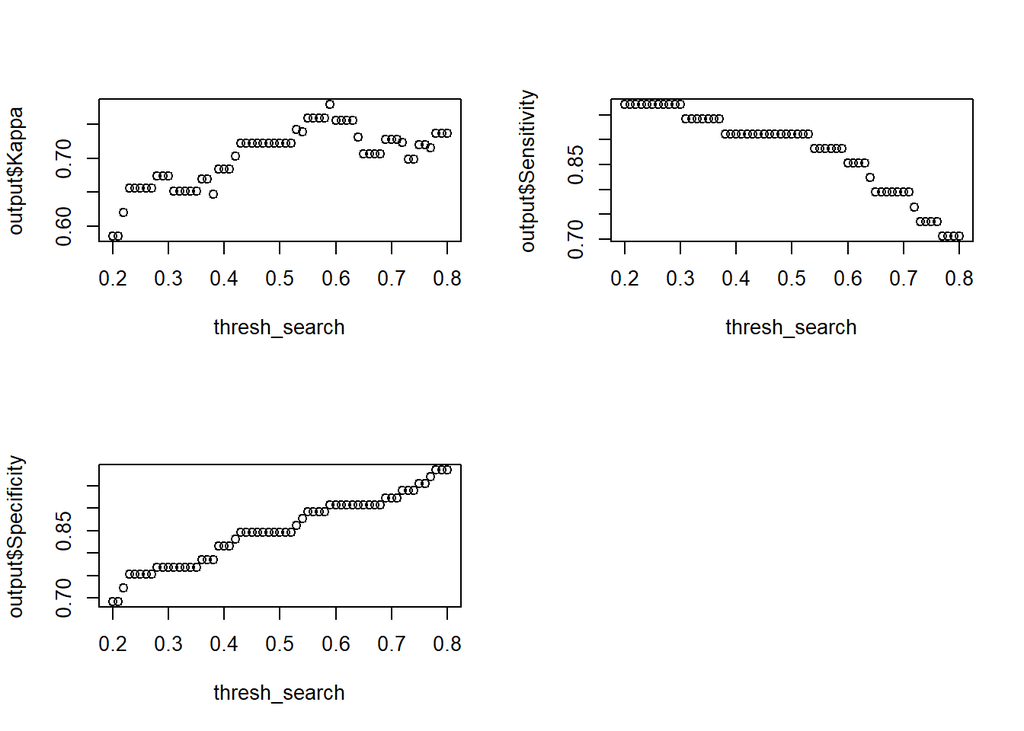

## Best Backwards Stepwise Log Regression Model

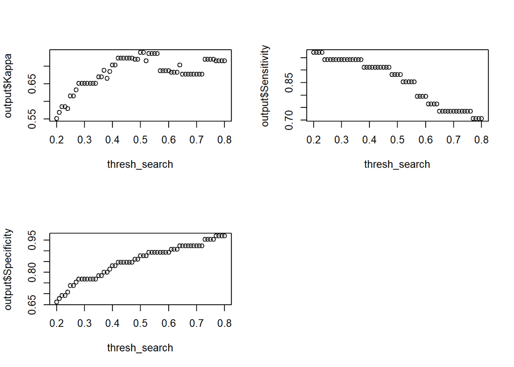

## Best Forward Stepwise Log Regression Model

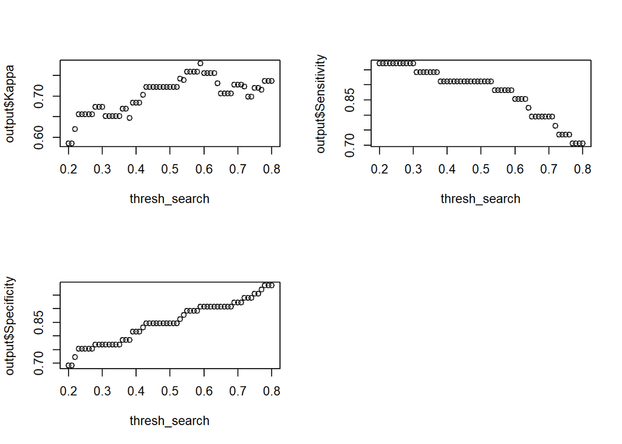

# Create Base level Test Predictions Output for the Log Regression Methods

```r
head(decision_tree_train_log_model_output, 8)
```

```
##     Base_Log_Kappa Base_Log_Sensitivity Base_Log_Specificity Backward_Log_Kappa
## 221              B                    B                    B                  B
## 491              M                    M                    B                  M
## 51               M                    M                    M                  M
## 258              M                    M                    B                  M
## 409              M                    M                    M                  M
## 47               B                    B                    B                  B
## 436              B                    B                    B                  B
## 382              B                    B                    B                  B
##     Backward_Log_Sensitivity Backward_Log_Specificity Forward_Log_Kappa
## 221                        B                        B                 B
## 491                        M                        B                 M
## 51                         M                        M                 M
## 258                        M                        B                 M
## 409                        M                        M                 M
## 47                         B                        B                 B
## 436                        B                        B                 B
## 382                        B                        B                 B
##     Forward_Log_Sensitivity Forward_Log_Specificity Actual
## 221                       B                       B      B
## 491                       M                       B      M
## 51                        M                       M      M
## 258                       M                       B      B
## 409                       M                       M      M
## 47                        B                       B      B
## 436                       B                       B      B
## 382                       B                       B      B
```

# Analyze Individual Model Results

## Base Log Highest Kappa Model

```r
# Confusion Matrix
confusionMatrix(decision_tree_train_log_model_output$Base_Log_Kappa, decision_tree_train_log_model_output$Actual, positive = "M")
```

```
## Confusion Matrix and Statistics
##
##           Reference
## Prediction  B  M
##          B 59  4
##          M  6 30
##
##                Accuracy : 0.899
##                  95% CI : (0.8221, 0.9505)
##     No Information Rate : 0.6566
##     P-Value [Acc > NIR] : 0.0000000245
##
##                   Kappa : 0.7791
##
##  Mcnemar's Test P-Value : 0.7518
##
##             Sensitivity : 0.8824
##             Specificity : 0.9077
##          Pos Pred Value : 0.8333
##          Neg Pred Value : 0.9365
##              Prevalence : 0.3434
##          Detection Rate : 0.3030
##    Detection Prevalence : 0.3636
##       Balanced Accuracy : 0.8950
##
##        'Positive' Class : M
##
```

## Base Log: Selected Sensitivity

```r
# Confusion Matrix
confusionMatrix(decision_tree_train_log_model_output$Base_Log_Sensitivity, decision_tree_train_log_model_output$Actual, positive = "M")
```

```
## Confusion Matrix and Statistics
##
##           Reference
## Prediction  B  M
##          B 50  2
##          M 15 32
##
##                Accuracy : 0.8283
##                  95% CI : (0.7394, 0.8967)
##     No Information Rate : 0.6566
##     P-Value [Acc > NIR] : 0.0001183
##
##                   Kappa : 0.651
##
##  Mcnemar's Test P-Value : 0.0036093
##
##             Sensitivity : 0.9412
##             Specificity : 0.7692
##          Pos Pred Value : 0.6809
##          Neg Pred Value : 0.9615
##              Prevalence : 0.3434
##          Detection Rate : 0.3232
##    Detection Prevalence : 0.4747
##       Balanced Accuracy : 0.8552
##
##        'Positive' Class : M
##
```

## Base Log: Selected Specificity

```r
# Confusion Matrix
confusionMatrix(decision_tree_train_log_model_output$Base_Log_Specificity, decision_tree_train_log_model_output$Actual, positive = "M")
```

```
## Confusion Matrix and Statistics
##
##           Reference
## Prediction  B  M
##          B 62  9
##          M  3 25
##
##                Accuracy : 0.8788
##                  95% CI : (0.7978, 0.9358)
##     No Information Rate : 0.6566
##     P-Value [Acc > NIR] : 0.0000004224
##
##                   Kappa : 0.7194
##
##  Mcnemar's Test P-Value : 0.1489
##
##             Sensitivity : 0.7353
##             Specificity : 0.9538
##          Pos Pred Value : 0.8929
##          Neg Pred Value : 0.8732
##              Prevalence : 0.3434
##          Detection Rate : 0.2525
##    Detection Prevalence : 0.2828
##       Balanced Accuracy : 0.8446
##
##        'Positive' Class : M
##
```

## Backwards Log: Highest Kappa

```r
# Confusion Matrix
confusionMatrix(decision_tree_train_log_model_output$Backward_Log_Kappa, decision_tree_train_log_model_output$Actual, positive = "M")
```

```
## Confusion Matrix and Statistics
##
##           Reference
## Prediction  B  M
##          B 57  4
##          M  8 30
##
##                Accuracy : 0.8788
##                  95% CI : (0.7978, 0.9358)
##     No Information Rate : 0.6566
##     P-Value [Acc > NIR] : 0.0000004224
##
##                   Kappa : 0.7386
##
##  Mcnemar's Test P-Value : 0.3865
##
##             Sensitivity : 0.8824
##             Specificity : 0.8769
##          Pos Pred Value : 0.7895
##          Neg Pred Value : 0.9344
##              Prevalence : 0.3434
##          Detection Rate : 0.3030
##    Detection Prevalence : 0.3838
##       Balanced Accuracy : 0.8796
##
##        'Positive' Class : M
##
```

## Backwards Log: Selected Sensitivity

```r
# Confusion Matrix
confusionMatrix(decision_tree_train_log_model_output$Backward_Log_Sensitivity, decision_tree_train_log_model_output$Actual, positive = "M")
```

```
## Confusion Matrix and Statistics
##
##           Reference
## Prediction  B  M
##          B 46  2
##          M 19 32
##
##                Accuracy : 0.7879
##                  95% CI : (0.6942, 0.8636)
##     No Information Rate : 0.6566
##     P-Value [Acc > NIR] : 0.0031214
##
##                   Kappa : 0.5797
##
##  Mcnemar's Test P-Value : 0.0004803
##
##             Sensitivity : 0.9412
##             Specificity : 0.7077
##          Pos Pred Value : 0.6275
##          Neg Pred Value : 0.9583
##              Prevalence : 0.3434
##          Detection Rate : 0.3232
##    Detection Prevalence : 0.5152
##       Balanced Accuracy : 0.8244
##
##        'Positive' Class : M
##
```

## Backwards Log: Selected Specificity

```r
# Confusion Matrix
confusionMatrix(decision_tree_train_log_model_output$Backward_Log_Specificity, decision_tree_train_log_model_output$Actual, positive = "M")
```

```
## Confusion Matrix and Statistics
##
##           Reference
## Prediction  B  M
##          B 62  9
##          M  3 25
##
##                Accuracy : 0.8788
##                  95% CI : (0.7978, 0.9358)
##     No Information Rate : 0.6566
##     P-Value [Acc > NIR] : 0.0000004224
##
##                   Kappa : 0.7194
##
##  Mcnemar's Test P-Value : 0.1489
##
##             Sensitivity : 0.7353
##             Specificity : 0.9538
##          Pos Pred Value : 0.8929
##          Neg Pred Value : 0.8732
##              Prevalence : 0.3434
##          Detection Rate : 0.2525
##    Detection Prevalence : 0.2828
##       Balanced Accuracy : 0.8446
##
##        'Positive' Class : M
##
```

## Forward Log: Highest Kappa

```r
# Confusion Matrix
confusionMatrix(decision_tree_train_log_model_output$Forward_Log_Kappa, decision_tree_train_log_model_output$Actual, positive = "M")
```

```
## Confusion Matrix and Statistics
##
##           Reference
## Prediction  B  M
##          B 59  4
##          M  6 30
##
##                Accuracy : 0.899
##                  95% CI : (0.8221, 0.9505)
##     No Information Rate : 0.6566
##     P-Value [Acc > NIR] : 0.0000000245
##
##                   Kappa : 0.7791
##
##  Mcnemar's Test P-Value : 0.7518
##
##             Sensitivity : 0.8824
##             Specificity : 0.9077
##          Pos Pred Value : 0.8333
##          Neg Pred Value : 0.9365
##              Prevalence : 0.3434
##          Detection Rate : 0.3030
##    Detection Prevalence : 0.3636
##       Balanced Accuracy : 0.8950
##
##        'Positive' Class : M
##
```

## Forward Log: Selected Sensitivity

```r
# Confusion Matrix
confusionMatrix(decision_tree_train_log_model_output$Forward_Log_Sensitivity, decision_tree_train_log_model_output$Actual, positive = "M")
```

```
## Confusion Matrix and Statistics
##
##           Reference
## Prediction  B  M
##          B 50  2
##          M 15 32
##
##                Accuracy : 0.8283
##                  95% CI : (0.7394, 0.8967)
##     No Information Rate : 0.6566
##     P-Value [Acc > NIR] : 0.0001183
##
##                   Kappa : 0.651
##
##  Mcnemar's Test P-Value : 0.0036093
##
##             Sensitivity : 0.9412
##             Specificity : 0.7692
##          Pos Pred Value : 0.6809
##          Neg Pred Value : 0.9615
##              Prevalence : 0.3434
##          Detection Rate : 0.3232
##    Detection Prevalence : 0.4747
##       Balanced Accuracy : 0.8552
##
##        'Positive' Class : M
##
```

## Forward Log: Selected Specificity

```r
# Confusion Matrix
confusionMatrix(decision_tree_train_log_model_output$Forward_Log_Specificity, decision_tree_train_log_model_output$Actual, positive = "M")
```

```
## Confusion Matrix and Statistics
##
##           Reference
## Prediction  B  M
##          B 62  9
##          M  3 25
##
##                Accuracy : 0.8788
##                  95% CI : (0.7978, 0.9358)
##     No Information Rate : 0.6566
##     P-Value [Acc > NIR] : 0.0000004224
##
##                   Kappa : 0.7194
##
##  Mcnemar's Test P-Value : 0.1489
##
##             Sensitivity : 0.7353
##             Specificity : 0.9538
##          Pos Pred Value : 0.8929
##          Neg Pred Value : 0.8732
##              Prevalence : 0.3434
##          Detection Rate : 0.2525
##    Detection Prevalence : 0.2828
##       Balanced Accuracy : 0.8446
##
##        'Positive' Class : M
##
```

# Train Decision Tree

# Plot Log Regression Decision Logic

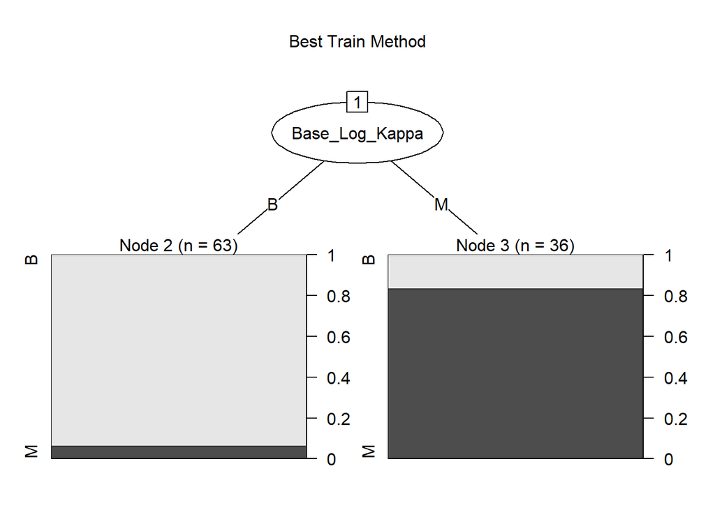

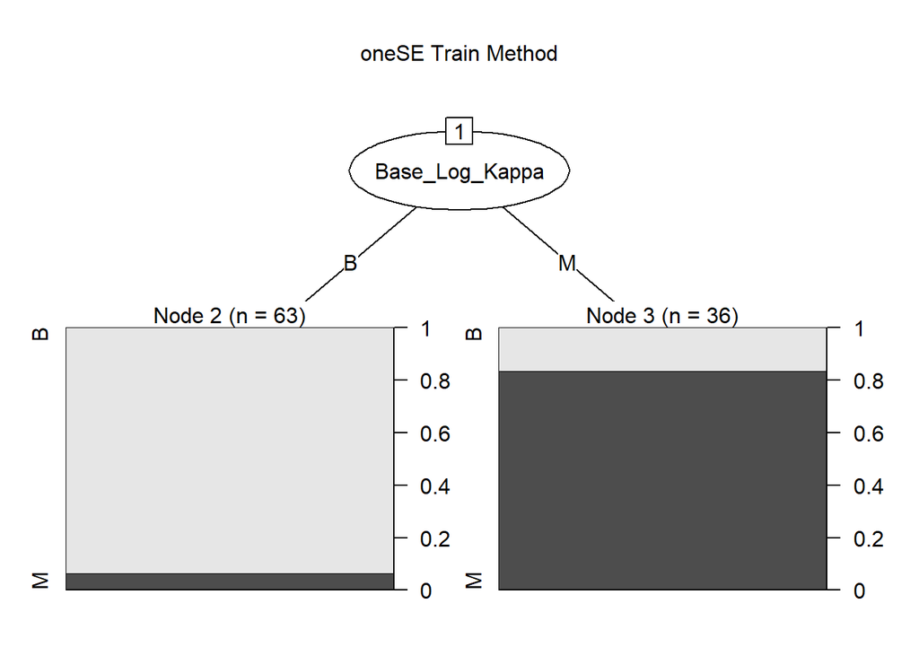

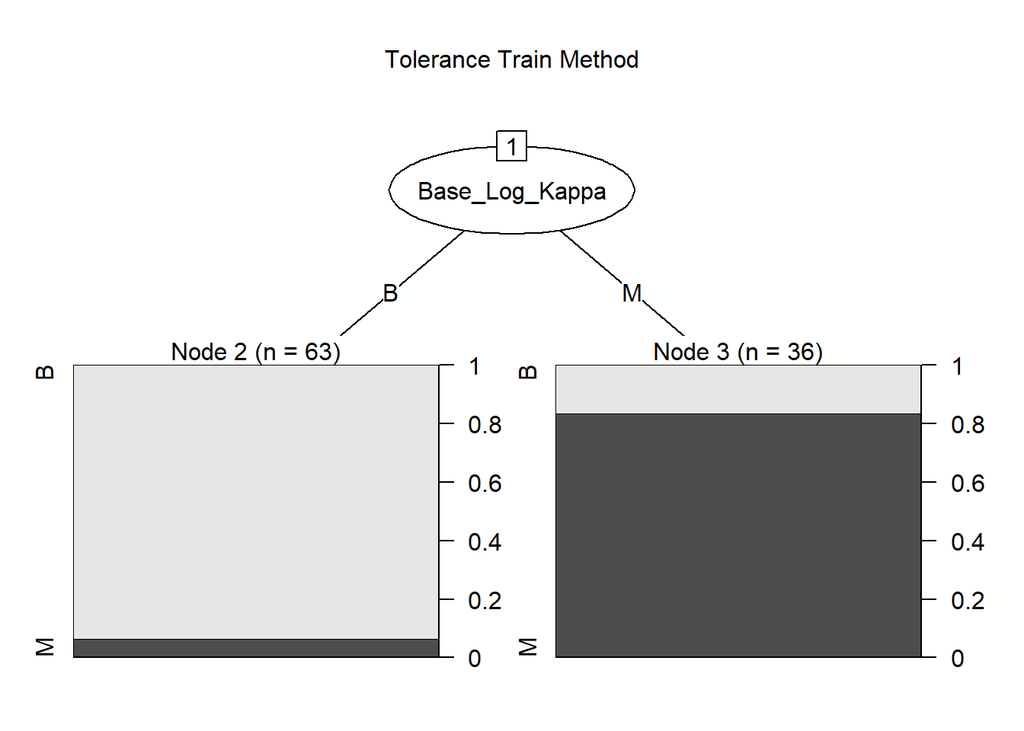

# Check Base level Tree Results Logistic Regression

## Best

```r
base_best_log_tree_pred <-  predict(base_best_tree_log_model_selector, newdata = decision_tree_train_log_model_output, "raw")
confusionMatrix(as.factor(base_best_log_tree_pred), decision_tree_train_log_model_output$Actual, positive = "M")
```

```
## Confusion Matrix and Statistics
##
##           Reference
## Prediction  B  M
##          B 59  4
##          M  6 30
##
##                Accuracy : 0.899
##                  95% CI : (0.8221, 0.9505)
##     No Information Rate : 0.6566
##     P-Value [Acc > NIR] : 0.0000000245
##
##                   Kappa : 0.7791
##
##  Mcnemar's Test P-Value : 0.7518
##
##             Sensitivity : 0.8824
##             Specificity : 0.9077
##          Pos Pred Value : 0.8333
##          Neg Pred Value : 0.9365
##              Prevalence : 0.3434
##          Detection Rate : 0.3030
##    Detection Prevalence : 0.3636
##       Balanced Accuracy : 0.8950
##
##        'Positive' Class : M
##
```

## OneSE

```r
base_oneSE_log_tree_pred <-  predict(base_oneSE_tree_log_model_selector, newdata = decision_tree_train_log_model_output, "raw")
confusionMatrix(as.factor(base_oneSE_log_tree_pred), decision_tree_train_log_model_output$Actual, positive = "M")
```

```
## Confusion Matrix and Statistics
##
##           Reference
## Prediction  B  M
##          B 59  4
##          M  6 30
##
##                Accuracy : 0.899
##                  95% CI : (0.8221, 0.9505)
##     No Information Rate : 0.6566
##     P-Value [Acc > NIR] : 0.0000000245
##
##                   Kappa : 0.7791
##
##  Mcnemar's Test P-Value : 0.7518
##
##             Sensitivity : 0.8824
##             Specificity : 0.9077
##          Pos Pred Value : 0.8333
##          Neg Pred Value : 0.9365
##              Prevalence : 0.3434
##          Detection Rate : 0.3030
##    Detection Prevalence : 0.3636
##       Balanced Accuracy : 0.8950
##
##        'Positive' Class : M
##
```

## Tolerance

```r
base_tolerance_log_tree_pred <-  predict(base_tolerance_tree_log_model_selector, newdata = decision_tree_train_log_model_output, "raw")
confusionMatrix(as.factor(base_tolerance_log_tree_pred), decision_tree_train_log_model_output$Actual, positive = "M")
```

```
## Confusion Matrix and Statistics
##
##           Reference
## Prediction  B  M
##          B 59  4
##          M  6 30
##
##                Accuracy : 0.899
##                  95% CI : (0.8221, 0.9505)
##     No Information Rate : 0.6566
##     P-Value [Acc > NIR] : 0.0000000245
##
##                   Kappa : 0.7791
##
##  Mcnemar's Test P-Value : 0.7518
##
##             Sensitivity : 0.8824
##             Specificity : 0.9077
##          Pos Pred Value : 0.8333
##          Neg Pred Value : 0.9365
##              Prevalence : 0.3434
##          Detection Rate : 0.3030
##    Detection Prevalence : 0.3636
##       Balanced Accuracy : 0.8950
##
##        'Positive' Class : M
##
```

# KNN

```r
base_level_train_knn_upsampled <- upSample(x = base_level_train_knn[,-ncol(base_level_train_knn)], y = base_level_train_knn$diagnosis)
base_level_train_knn_upsampled$diagnosis <- base_level_train_knn_upsampled$Class

base_level_train_knn_upsampled$Class <- NULL

koption <- round(sqrt(nrow(base_level_train_knn_upsampled)),0)

koption
```

```
## [1] 16
```

```r
ctrl <- trainControl(method = "cv", number = global_cv_folds, selectionFunction = "best")

grid <- expand.grid(k = seq(2, 100))

set.seed(23)
base_knn_best <- train(diagnosis~., data = base_level_train_knn_upsampled, method = "knn",
                       metric = "Kappa",
                       trControl = ctrl,
                       tuneGrid = grid)



ctrl <- trainControl(method = "cv", number = global_cv_folds, selectionFunction = "oneSE")

grid <- expand.grid(k = seq(2, 100))

set.seed(23)
base_knn_oneSE <- train(diagnosis~., data = base_level_train_knn_upsampled, method = "knn",
                        metric = "Kappa",
                        trControl = ctrl,
                        tuneGrid = grid)


ctrl <- trainControl(method = "cv", number = global_cv_folds, selectionFunction = "tolerance")

grid <- expand.grid(k = seq(2, 100))

set.seed(23)
base_knn_tolerance <- train(diagnosis~., data = base_level_train_knn_upsampled, method = "knn",
                            metric = "Kappa",
                            trControl = ctrl,
                            tuneGrid = grid)
```

# Create Predictions

```r
# Create Predictions
base_knn_best_pred <- predict(base_knn_best, newdata = base_level_test_knn, type = "prob")[,2]
base_knn_oneSE_pred <- predict(base_knn_oneSE, newdata = base_level_test_knn, type = "prob")[,2]
base_knn_tolerance_pred <- predict(base_knn_tolerance, newdata = base_level_test_knn, type = "prob")[,2]
```

# Optimize Prediction Threshold

## Base “Best” KNN Model

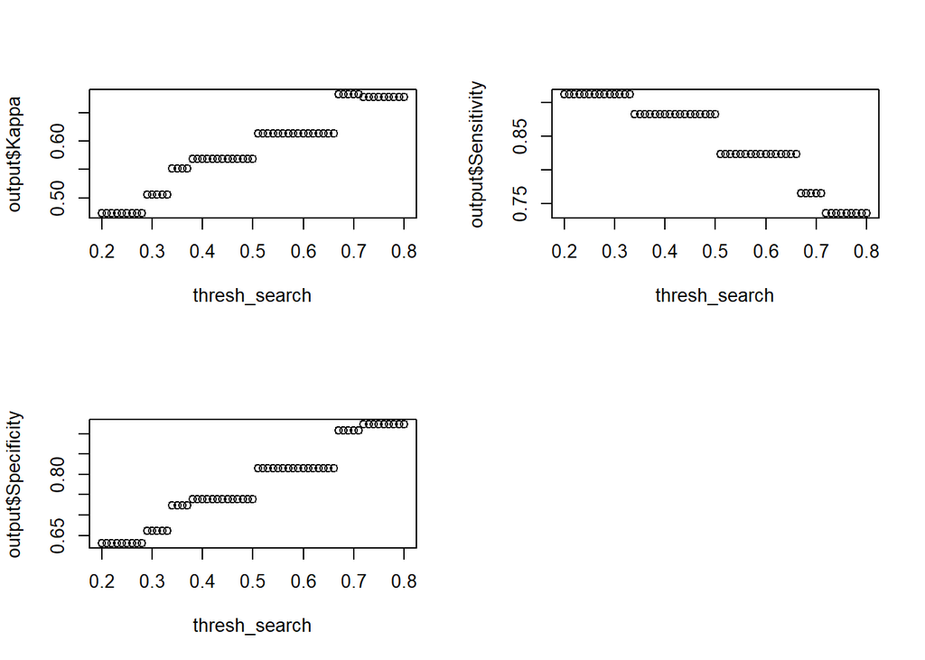

## Base “oneSE” KNN Model

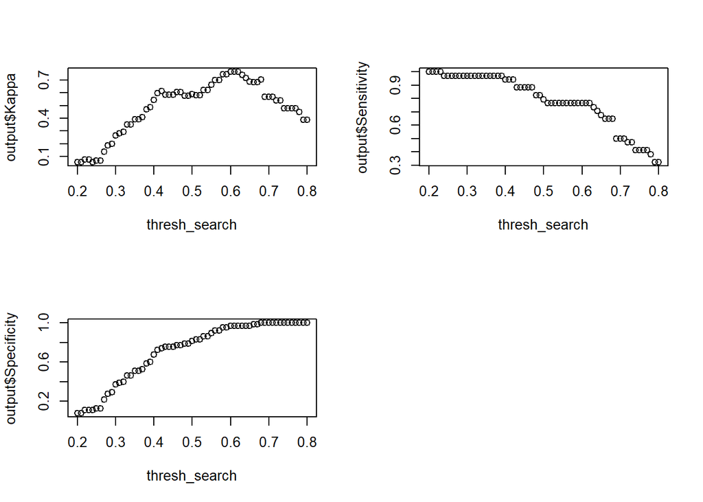

## Base “Tolerance” KNN Model

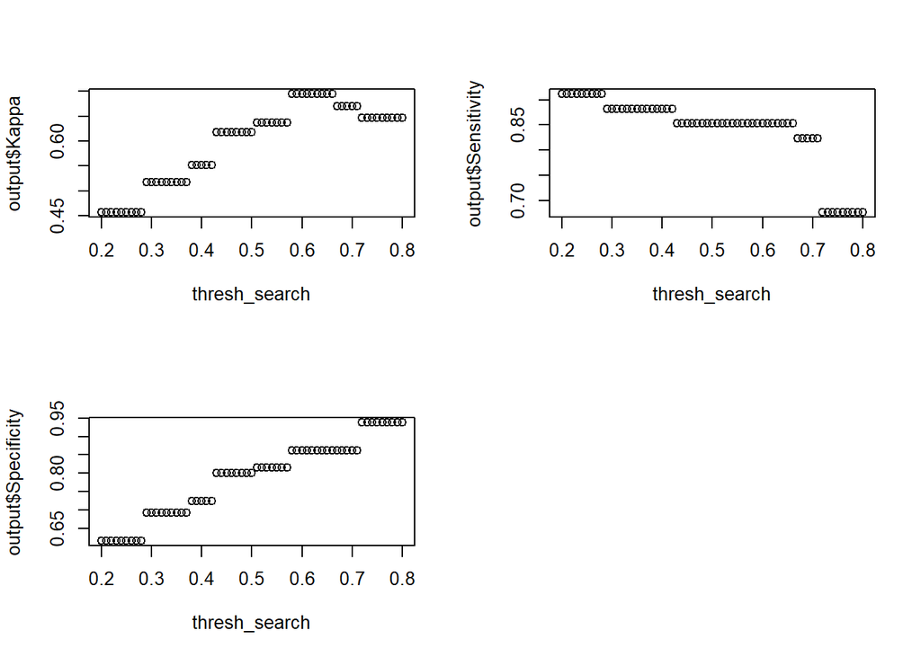

# Create Base level Test Predictions Output for the KNN Methods

```r
head(decision_tree_train_knn_model_output, 8)
```

```
##   Base_Best_KNN_Kappa Base_Best_KNN_Sensitivity Base_Best_KNN_Specificity
## 1                   B                         B                         B
## 2                   B                         M                         B
## 3                   M                         M                         M
## 4                   M                         M                         M
## 5                   M                         M                         M
## 6                   B                         B                         B
## 7                   B                         B                         B
## 8                   B                         B                         B
##   Base_oneSE_KNN_Kappa Base_oneSE_KNN_Sensitivity Base_oneSE_KNN_Specificity
## 1                    B                          B                          B
## 2                    B                          M                          B
## 3                    M                          M                          M
## 4                    B                          M                          B
## 5                    M                          M                          M
```

[output cut: 21 more lines]

# Analyze Individual Model Results

## Base Best KNN Highest Kappa Model

```r
# Confusion Matrix
confusionMatrix(decision_tree_train_knn_model_output$Base_Best_KNN_Kappa, decision_tree_train_knn_model_output$Actual, positive = "M")
```

```
## Confusion Matrix and Statistics
##
##           Reference
## Prediction  B  M
##          B 59  8
##          M  6 26
##
##                Accuracy : 0.8586
##                  95% CI : (0.7741, 0.9205)
##     No Information Rate : 0.6566
##     P-Value [Acc > NIR] : 0.000005077
##
##                   Kappa : 0.682
##
##  Mcnemar's Test P-Value : 0.7893
##
##             Sensitivity : 0.7647
##             Specificity : 0.9077
##          Pos Pred Value : 0.8125
##          Neg Pred Value : 0.8806
##              Prevalence : 0.3434
##          Detection Rate : 0.2626
##    Detection Prevalence : 0.3232
##       Balanced Accuracy : 0.8362
##
##        'Positive' Class : M
##
```

## Base Best KNN: Selected Sensitivity

```r
# Confusion Matrix
confusionMatrix(decision_tree_train_knn_model_output$Base_Best_KNN_Sensitivity, decision_tree_train_knn_model_output$Actual, positive = "M")
```

```
## Confusion Matrix and Statistics
##
##           Reference
## Prediction  B  M
##          B 41  3
##          M 24 31
##
##                Accuracy : 0.7273
##                  95% CI : (0.6285, 0.812)
##     No Information Rate : 0.6566
##     P-Value [Acc > NIR] : 0.0826626
##
##                   Kappa : 0.4729
##
##  Mcnemar's Test P-Value : 0.0001186
##
##             Sensitivity : 0.9118
##             Specificity : 0.6308
##          Pos Pred Value : 0.5636
##          Neg Pred Value : 0.9318
##              Prevalence : 0.3434
##          Detection Rate : 0.3131
##    Detection Prevalence : 0.5556
##       Balanced Accuracy : 0.7713
##
##        'Positive' Class : M
##
```

## Base Best KNN: Selected Specificity

```r
# Confusion Matrix
confusionMatrix(decision_tree_train_knn_model_output$Base_Best_KNN_Specificity, decision_tree_train_knn_model_output$Actual, positive = "M")
```

```
## Confusion Matrix and Statistics
##
##           Reference
## Prediction  B  M
##          B 60  9
##          M  5 25
##
##                Accuracy : 0.8586
##                  95% CI : (0.7741, 0.9205)
##     No Information Rate : 0.6566
##     P-Value [Acc > NIR] : 0.000005077
##
##                   Kappa : 0.6774
##
##  Mcnemar's Test P-Value : 0.4227
##
##             Sensitivity : 0.7353
##             Specificity : 0.9231
##          Pos Pred Value : 0.8333
##          Neg Pred Value : 0.8696
##              Prevalence : 0.3434
##          Detection Rate : 0.2525
##    Detection Prevalence : 0.3030
##       Balanced Accuracy : 0.8292
##
##        'Positive' Class : M
##
```

## Base oneSE KNN: Highest Kappa

```r
# Confusion Matrix
confusionMatrix(decision_tree_train_knn_model_output$Base_oneSE_KNN_Kappa, decision_tree_train_knn_model_output$Actual, positive = "M")
```

```
## Confusion Matrix and Statistics
##
##           Reference
## Prediction  B  M
##          B 63  8
##          M  2 26
##
##                Accuracy : 0.899
##                  95% CI : (0.8221, 0.9505)
##     No Information Rate : 0.6566
##     P-Value [Acc > NIR] : 0.0000000245
##
##                   Kappa : 0.7662
##
##  Mcnemar's Test P-Value : 0.1138
##
##             Sensitivity : 0.7647
##             Specificity : 0.9692
##          Pos Pred Value : 0.9286
##          Neg Pred Value : 0.8873
##              Prevalence : 0.3434
##          Detection Rate : 0.2626
##    Detection Prevalence : 0.2828
##       Balanced Accuracy : 0.8670
##
##        'Positive' Class : M
##
```

## Base oneSE KNN: Selected Sensitivity

```r
# Confusion Matrix
confusionMatrix(decision_tree_train_knn_model_output$Base_oneSE_KNN_Sensitivity, decision_tree_train_knn_model_output$Actual, positive = "M")
```

```
## Confusion Matrix and Statistics
##
##           Reference
## Prediction  B  M
##          B 44  2
##          M 21 32
##
##                Accuracy : 0.7677
##                  95% CI : (0.6721, 0.8467)
##     No Information Rate : 0.6566
##     P-Value [Acc > NIR] : 0.0113594
##
##                   Kappa : 0.5454
##
##  Mcnemar's Test P-Value : 0.0001746
##
##             Sensitivity : 0.9412
##             Specificity : 0.6769
##          Pos Pred Value : 0.6038
##          Neg Pred Value : 0.9565
##              Prevalence : 0.3434
##          Detection Rate : 0.3232
##    Detection Prevalence : 0.5354
##       Balanced Accuracy : 0.8090
##
##        'Positive' Class : M
##
```

## Base oneSE KNN: Selected Specificity

```r
# Confusion Matrix
confusionMatrix(decision_tree_train_knn_model_output$Base_oneSE_KNN_Specificity, decision_tree_train_knn_model_output$Actual, positive = "M")
```

```
## Confusion Matrix and Statistics
##
##           Reference
## Prediction  B  M
##          B 62  8
##          M  3 26
##
##                Accuracy : 0.8889
##                  95% CI : (0.8099, 0.9432)
##     No Information Rate : 0.6566
##     P-Value [Acc > NIR] : 0.0000001068
##
##                   Kappa : 0.7447
##
##  Mcnemar's Test P-Value : 0.2278
##
##             Sensitivity : 0.7647
##             Specificity : 0.9538
##          Pos Pred Value : 0.8966
##          Neg Pred Value : 0.8857
##              Prevalence : 0.3434
##          Detection Rate : 0.2626
##    Detection Prevalence : 0.2929
##       Balanced Accuracy : 0.8593
##
##        'Positive' Class : M
##
```

## Base Tolerance KNN: Highest Kappa

```r
# Confusion Matrix
confusionMatrix(decision_tree_train_knn_model_output$Base_Tolerance_KNN_Kappa, decision_tree_train_knn_model_output$Actual, positive = "M")
```

```
## Confusion Matrix and Statistics
##
##           Reference
## Prediction  B  M
##          B 56  5
##          M  9 29
##
##                Accuracy : 0.8586
##                  95% CI : (0.7741, 0.9205)
##     No Information Rate : 0.6566
##     P-Value [Acc > NIR] : 0.000005077
##
##                   Kappa : 0.695
##
##  Mcnemar's Test P-Value : 0.4227
##
##             Sensitivity : 0.8529
##             Specificity : 0.8615
##          Pos Pred Value : 0.7632
##          Neg Pred Value : 0.9180
##              Prevalence : 0.3434
##          Detection Rate : 0.2929
##    Detection Prevalence : 0.3838
##       Balanced Accuracy : 0.8572
##
##        'Positive' Class : M
##
```

## Base Tolerance KNN: Selected Sensitivity

```r
# Confusion Matrix
confusionMatrix(decision_tree_train_knn_model_output$Base_Tolerance_KNN_Sensitivity, decision_tree_train_knn_model_output$Actual, positive = "M")
```

```
## Confusion Matrix and Statistics
##
##           Reference
## Prediction  B  M
##          B 40  3
##          M 25 31
##
##                Accuracy : 0.7172
##                  95% CI : (0.6178, 0.8031)
##     No Information Rate : 0.6566
##     P-Value [Acc > NIR] : 0.1213
##
##                   Kappa : 0.4567
##
##  Mcnemar's Test P-Value : 0.00007229
##
##             Sensitivity : 0.9118
##             Specificity : 0.6154
##          Pos Pred Value : 0.5536
##          Neg Pred Value : 0.9302
##              Prevalence : 0.3434
##          Detection Rate : 0.3131
##    Detection Prevalence : 0.5657
##       Balanced Accuracy : 0.7636
##
##        'Positive' Class : M
##
```

## Base Tolerance KNN: Selected Specificity

```r
# Confusion Matrix
confusionMatrix(decision_tree_train_knn_model_output$Base_Tolerance_KNN_Specificity, decision_tree_train_knn_model_output$Actual, positive = "M")
```

```
## Confusion Matrix and Statistics
##
##           Reference
## Prediction  B  M
##          B 61 11
##          M  4 23
##
##                Accuracy : 0.8485
##                  95% CI : (0.7624, 0.9126)
##     No Information Rate : 0.6566
##     P-Value [Acc > NIR] : 0.0000156
##
##                   Kappa : 0.6467
##
##  Mcnemar's Test P-Value : 0.1213
##
##             Sensitivity : 0.6765
##             Specificity : 0.9385
##          Pos Pred Value : 0.8519
##          Neg Pred Value : 0.8472
##              Prevalence : 0.3434
##          Detection Rate : 0.2323
##    Detection Prevalence : 0.2727
##       Balanced Accuracy : 0.8075
##
##        'Positive' Class : M
##
```

# Train Decision Tree

# Plot KNN Decision Logic

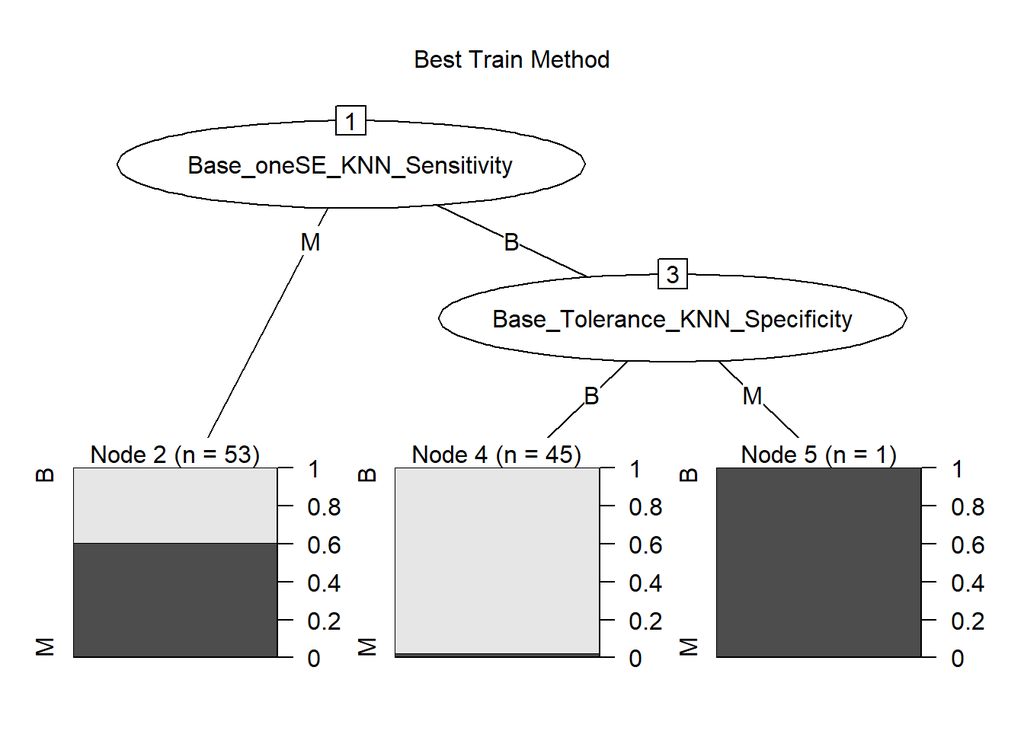

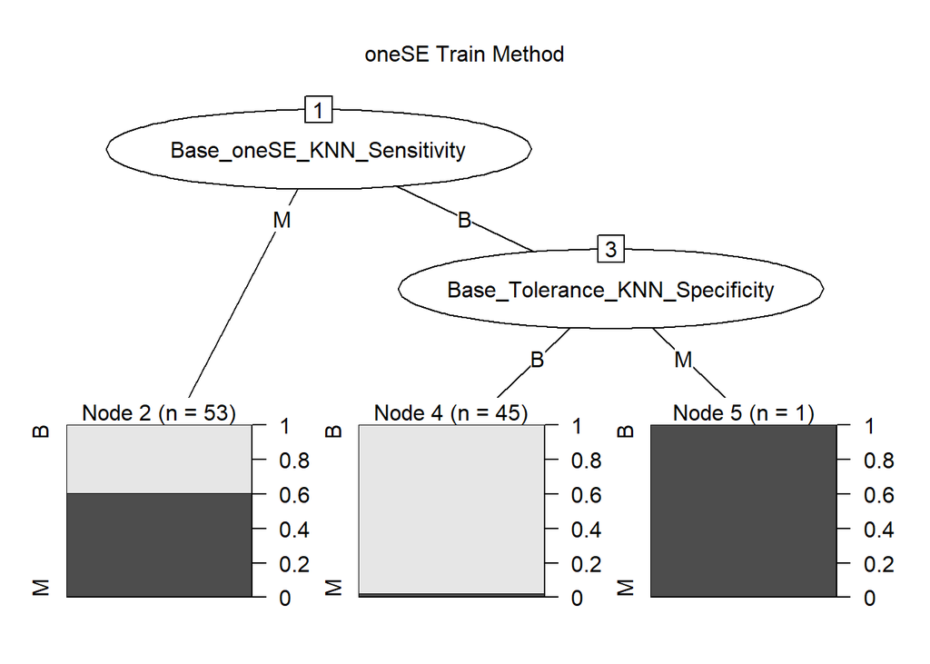

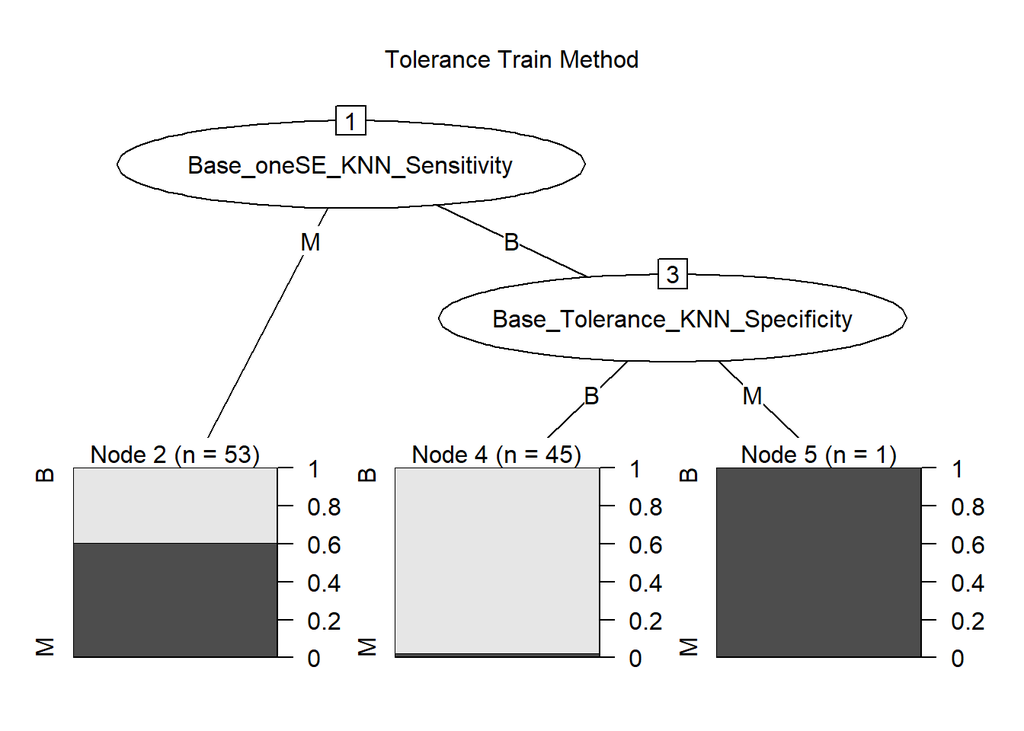

# Check Base level Tree Results KNN

## Best

```r
base_best_knn_tree_pred <-  predict(base_best_tree_knn_model_selector, newdata = decision_tree_train_knn_model_output, "raw")
confusionMatrix(as.factor(base_best_knn_tree_pred), decision_tree_train_knn_model_output$Actual, positive = "M")
```

```
## Confusion Matrix and Statistics
##
##           Reference
## Prediction  B  M
##          B 63  8
##          M  2 26
##
##                Accuracy : 0.899
##                  95% CI : (0.8221, 0.9505)
##     No Information Rate : 0.6566
##     P-Value [Acc > NIR] : 0.0000000245
##
##                   Kappa : 0.7662
##
##  Mcnemar's Test P-Value : 0.1138
##
##             Sensitivity : 0.7647
##             Specificity : 0.9692
##          Pos Pred Value : 0.9286
##          Neg Pred Value : 0.8873
##              Prevalence : 0.3434
##          Detection Rate : 0.2626
##    Detection Prevalence : 0.2828
##       Balanced Accuracy : 0.8670
##
##        'Positive' Class : M
##
```

## OneSE

```r
base_oneSE_knn_tree_pred <-  predict(base_oneSE_tree_knn_model_selector, newdata = decision_tree_train_knn_model_output, "raw")
confusionMatrix(as.factor(base_oneSE_knn_tree_pred), decision_tree_train_knn_model_output$Actual, positive = "M")
```

```
## Confusion Matrix and Statistics
##
##           Reference
## Prediction  B  M
##          B 44  1
##          M 21 33
##
##                Accuracy : 0.7778
##                  95% CI : (0.6831, 0.8552)
##     No Information Rate : 0.6566
##     P-Value [Acc > NIR] : 0.006116
##
##                   Kappa : 0.5679
##
##  Mcnemar's Test P-Value : 0.00005104
##
##             Sensitivity : 0.9706
##             Specificity : 0.6769
##          Pos Pred Value : 0.6111
##          Neg Pred Value : 0.9778
##              Prevalence : 0.3434
##          Detection Rate : 0.3333
##    Detection Prevalence : 0.5455
##       Balanced Accuracy : 0.8238
##
##        'Positive' Class : M
##
```

## Tolerance

```r
base_tolerance_knn_tree_pred <-  predict(base_tolerance_tree_knn_model_selector, newdata = decision_tree_train_knn_model_output, "raw")
confusionMatrix(as.factor(base_tolerance_knn_tree_pred), decision_tree_train_knn_model_output$Actual, positive = "M")
```

```
## Confusion Matrix and Statistics
##
##           Reference
## Prediction  B  M
##          B 63  8
##          M  2 26
##
##                Accuracy : 0.899
##                  95% CI : (0.8221, 0.9505)
##     No Information Rate : 0.6566
##     P-Value [Acc > NIR] : 0.0000000245
##
##                   Kappa : 0.7662
##
##  Mcnemar's Test P-Value : 0.1138
##
##             Sensitivity : 0.7647
##             Specificity : 0.9692
##          Pos Pred Value : 0.9286
##          Neg Pred Value : 0.8873
##              Prevalence : 0.3434
##          Detection Rate : 0.2626
##    Detection Prevalence : 0.2828
##       Balanced Accuracy : 0.8670
##
##        'Positive' Class : M
##
```

# ANN

```r
base_level_train_ann_upsampled <- upSample(x = base_level_train_ann[,-ncol(base_level_train_ann)], y = base_level_train_ann$diagnosis)
base_level_train_ann_upsampled$diagnosis <- base_level_train_ann_upsampled$Class

base_level_train_ann_upsampled$Class <- NULL

size_parameter <- 1:20
decay_parameter <- 1:5

grid = expand.grid(size = size_parameter,
                   decay = decay_parameter)

ctrl <- trainControl(method = "cv", number = global_cv_folds, selectionFunction = "best")

set.seed(23)
base_ann_best <- train(diagnosis~., data = base_level_train_ann_upsampled, method = "nnet",
                       tuneGrid = grid,
                       metric = "Kappa",
                       trControl = ctrl)



ctrl <- trainControl(method = "cv", number = global_cv_folds, selectionFunction = "oneSE")


set.seed(23)
base_ann_oneSE <- train(diagnosis~., data = base_level_train_ann_upsampled, method = "nnet",
                        tuneGrid = grid,
                        metric = "Kappa",
                        trControl = ctrl)



ctrl <- trainControl(method = "cv", number = global_cv_folds, selectionFunction = "tolerance")


set.seed(23)
base_ann_tolerance <- train(diagnosis~., data = base_level_train_ann_upsampled, method = "nnet",
                            tuneGrid = grid,
                            metric = "Kappa",
                            trControl = ctrl)
```

# Create Predictions

```r
# Create Predictions
base_ann_best_pred <- predict(base_ann_best, newdata = base_level_test_ann, type = "prob")[,2]
base_ann_oneSE_pred <- predict(base_ann_oneSE, newdata = base_level_test_ann, type = "prob")[,2]
base_ann_tolerance_pred <- predict(base_ann_tolerance, newdata = base_level_test_ann, type = "prob")[,2]
```

# Optimize Prediction Threshold

## Base “Best” ANN Model

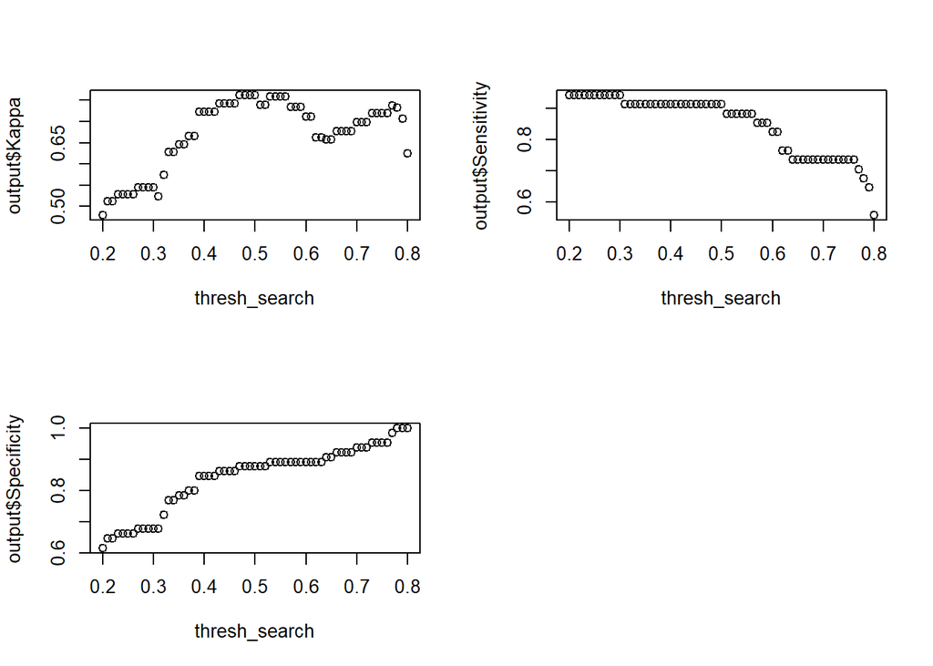

## Base “oneSE” ANN Model

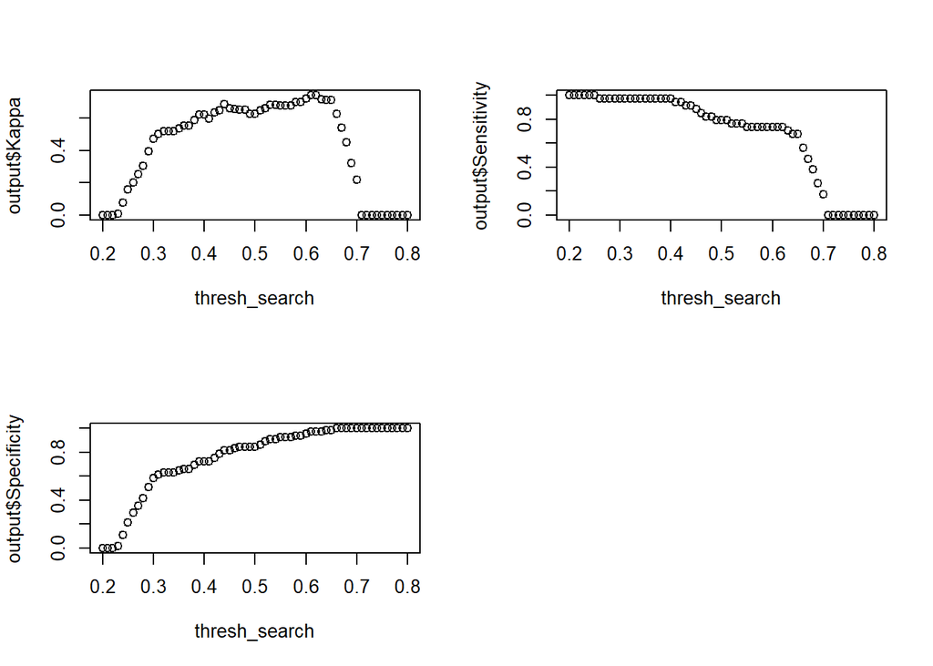

## Base “Tolerance” ANN Model

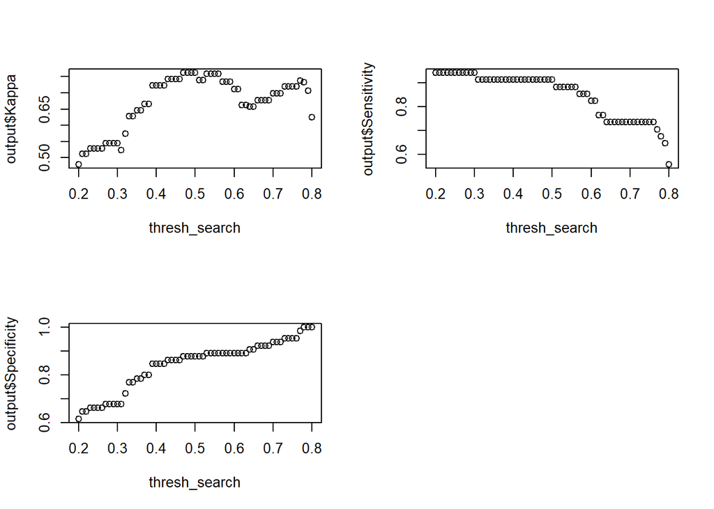

# Create Base level Test Predictions Output for the ANN Methods

```r
head(decision_tree_train_ann_model_output, 8)
```

```
##   Base_Best_ANN_Kappa Base_Best_ANN_Sensitivity Base_Best_ANN_Specificity
## 1                   B                         B                         B
## 2                   M                         M                         B
## 3                   M                         M                         M
## 4                   B                         M                         B
## 5                   M                         M                         M
## 6                   B                         B                         B
## 7                   B                         B                         B
## 8                   B                         B                         B
##   Base_oneSE_ANN_Kappa Base_oneSE_ANN_Sensitivity Base_oneSE_ANN_Specificity
## 1                    B                          B                          B
## 2                    B                          M                          B
## 3                    M                          M                          M
## 4                    B                          M                          B
## 5                    M                          M                          M
```

[output cut: 21 more lines]

# Analyze Individual Model Results

## Base Best ANN Highest Kappa Model

```r
# Confusion Matrix
confusionMatrix(decision_tree_train_ann_model_output$Base_Best_ANN_Kappa, decision_tree_train_ann_model_output$Actual, positive = "M")
```

```
## Confusion Matrix and Statistics
##
##           Reference
## Prediction  B  M
##          B 57  3
##          M  8 31
##
##                Accuracy : 0.8889
##                  95% CI : (0.8099, 0.9432)
##     No Information Rate : 0.6566
##     P-Value [Acc > NIR] : 0.0000001068
##
##                   Kappa : 0.762
##
##  Mcnemar's Test P-Value : 0.2278
##
##             Sensitivity : 0.9118
##             Specificity : 0.8769
##          Pos Pred Value : 0.7949
##          Neg Pred Value : 0.9500
##              Prevalence : 0.3434
##          Detection Rate : 0.3131
##    Detection Prevalence : 0.3939
##       Balanced Accuracy : 0.8943
##
##        'Positive' Class : M
##
```

## Base Best ANN: Selected Sensitivity

```r
# Confusion Matrix
confusionMatrix(decision_tree_train_ann_model_output$Base_Best_ANN_Sensitivity, decision_tree_train_ann_model_output$Actual, positive = "M")
```

```
## Confusion Matrix and Statistics
##
##           Reference
## Prediction  B  M
##          B 40  2
##          M 25 32
##
##                Accuracy : 0.7273
##                  95% CI : (0.6285, 0.812)
##     No Information Rate : 0.6566
##     P-Value [Acc > NIR] : 0.08266
##
##                   Kappa : 0.4793
##
##  Mcnemar's Test P-Value : 0.00002297
##
##             Sensitivity : 0.9412
##             Specificity : 0.6154
##          Pos Pred Value : 0.5614
##          Neg Pred Value : 0.9524
##              Prevalence : 0.3434
##          Detection Rate : 0.3232
##    Detection Prevalence : 0.5758
##       Balanced Accuracy : 0.7783
##
##        'Positive' Class : M
##
```

## Base Best ANN: Selected Specificity

```r
# Confusion Matrix
confusionMatrix(decision_tree_train_ann_model_output$Base_Best_ANN_Specificity, decision_tree_train_ann_model_output$Actual, positive = "M")
```

```
## Confusion Matrix and Statistics
##
##           Reference
## Prediction  B  M
##          B 62  9
##          M  3 25
##
##                Accuracy : 0.8788
##                  95% CI : (0.7978, 0.9358)
##     No Information Rate : 0.6566
##     P-Value [Acc > NIR] : 0.0000004224
##
##                   Kappa : 0.7194
##
##  Mcnemar's Test P-Value : 0.1489
##
##             Sensitivity : 0.7353
##             Specificity : 0.9538
##          Pos Pred Value : 0.8929
##          Neg Pred Value : 0.8732
##              Prevalence : 0.3434
##          Detection Rate : 0.2525
##    Detection Prevalence : 0.2828
##       Balanced Accuracy : 0.8446
##
##        'Positive' Class : M
##
```

## Base oneSE ANN: Highest Kappa

```r
# Confusion Matrix
confusionMatrix(decision_tree_train_ann_model_output$Base_oneSE_ANN_Kappa, decision_tree_train_ann_model_output$Actual, positive = "M")
```

```
## Confusion Matrix and Statistics
##
##           Reference
## Prediction  B  M
##          B 63  9
##          M  2 25
##
##                Accuracy : 0.8889
##                  95% CI : (0.8099, 0.9432)
##     No Information Rate : 0.6566
##     P-Value [Acc > NIR] : 0.0000001068
##
##                   Kappa : 0.7409
##
##  Mcnemar's Test P-Value : 0.07044
##
##             Sensitivity : 0.7353
##             Specificity : 0.9692
##          Pos Pred Value : 0.9259
##          Neg Pred Value : 0.8750
##              Prevalence : 0.3434
##          Detection Rate : 0.2525
##    Detection Prevalence : 0.2727
##       Balanced Accuracy : 0.8523
##
##        'Positive' Class : M
##
```

## Base oneSE ANN: Selected Sensitivity

```r
# Confusion Matrix
confusionMatrix(decision_tree_train_ann_model_output$Base_oneSE_ANN_Sensitivity, decision_tree_train_ann_model_output$Actual, positive = "M")
```

```
## Confusion Matrix and Statistics
##
##           Reference
## Prediction  B  M
##          B 47  2
##          M 18 32
##
##                Accuracy : 0.798
##                  95% CI : (0.7054, 0.872)
##     No Information Rate : 0.6566
##     P-Value [Acc > NIR] : 0.0015068
##
##                   Kappa : 0.5972
##
##  Mcnemar's Test P-Value : 0.0007962
##
##             Sensitivity : 0.9412
##             Specificity : 0.7231
##          Pos Pred Value : 0.6400
##          Neg Pred Value : 0.9592
##              Prevalence : 0.3434
##          Detection Rate : 0.3232
##    Detection Prevalence : 0.5051
##       Balanced Accuracy : 0.8321
##
##        'Positive' Class : M
##
```

## Base oneSE ANN: Selected Specificity

```r
# Confusion Matrix
confusionMatrix(decision_tree_train_ann_model_output$Base_oneSE_ANN_Specificity, decision_tree_train_ann_model_output$Actual, positive = "M")
```

```
## Confusion Matrix and Statistics
##
##           Reference
## Prediction  B  M
##          B 62  9
##          M  3 25
##
##                Accuracy : 0.8788
##                  95% CI : (0.7978, 0.9358)
##     No Information Rate : 0.6566
##     P-Value [Acc > NIR] : 0.0000004224
##
##                   Kappa : 0.7194
##
##  Mcnemar's Test P-Value : 0.1489
##
##             Sensitivity : 0.7353
##             Specificity : 0.9538
##          Pos Pred Value : 0.8929
##          Neg Pred Value : 0.8732
##              Prevalence : 0.3434
##          Detection Rate : 0.2525
##    Detection Prevalence : 0.2828
##       Balanced Accuracy : 0.8446
##
##        'Positive' Class : M
##
```

## Base Tolerance ANN: Highest Kappa

```r
# Confusion Matrix
confusionMatrix(decision_tree_train_ann_model_output$Base_Tolerance_ANN_Kappa, decision_tree_train_ann_model_output$Actual, positive = "M")
```

```
## Confusion Matrix and Statistics
##
##           Reference
## Prediction  B  M
##          B 57  3
##          M  8 31
##
##                Accuracy : 0.8889
##                  95% CI : (0.8099, 0.9432)
##     No Information Rate : 0.6566
##     P-Value [Acc > NIR] : 0.0000001068
##
##                   Kappa : 0.762
##
##  Mcnemar's Test P-Value : 0.2278
##
##             Sensitivity : 0.9118
##             Specificity : 0.8769
##          Pos Pred Value : 0.7949
##          Neg Pred Value : 0.9500
##              Prevalence : 0.3434
##          Detection Rate : 0.3131
##    Detection Prevalence : 0.3939
##       Balanced Accuracy : 0.8943
##
##        'Positive' Class : M
##
```

## Base Tolerance ANN: Selected Sensitivity

```r
# Confusion Matrix
confusionMatrix(decision_tree_train_ann_model_output$Base_Tolerance_ANN_Sensitivity, decision_tree_train_ann_model_output$Actual, positive = "M")
```

```
## Confusion Matrix and Statistics
##
##           Reference
## Prediction  B  M
##          B 40  2
##          M 25 32
##
##                Accuracy : 0.7273
##                  95% CI : (0.6285, 0.812)
##     No Information Rate : 0.6566
##     P-Value [Acc > NIR] : 0.08266
##
##                   Kappa : 0.4793
##
##  Mcnemar's Test P-Value : 0.00002297
##
##             Sensitivity : 0.9412
##             Specificity : 0.6154
##          Pos Pred Value : 0.5614
##          Neg Pred Value : 0.9524
##              Prevalence : 0.3434
##          Detection Rate : 0.3232
##    Detection Prevalence : 0.5758
##       Balanced Accuracy : 0.7783
##
##        'Positive' Class : M
##
```

## Base Tolerance ANN: Selected Specificity

```r
# Confusion Matrix
confusionMatrix(decision_tree_train_ann_model_output$Base_Tolerance_ANN_Specificity, decision_tree_train_ann_model_output$Actual, positive = "M")
```

```
## Confusion Matrix and Statistics
##
##           Reference
## Prediction  B  M
##          B 62  9
##          M  3 25
##
##                Accuracy : 0.8788
##                  95% CI : (0.7978, 0.9358)
##     No Information Rate : 0.6566
##     P-Value [Acc > NIR] : 0.0000004224
##
##                   Kappa : 0.7194
##
##  Mcnemar's Test P-Value : 0.1489
##
##             Sensitivity : 0.7353
##             Specificity : 0.9538
##          Pos Pred Value : 0.8929
##          Neg Pred Value : 0.8732
##              Prevalence : 0.3434
##          Detection Rate : 0.2525
##    Detection Prevalence : 0.2828
##       Balanced Accuracy : 0.8446
##
##        'Positive' Class : M
##
```

# Train Decision Tree

# Plot ANN Decision Logic

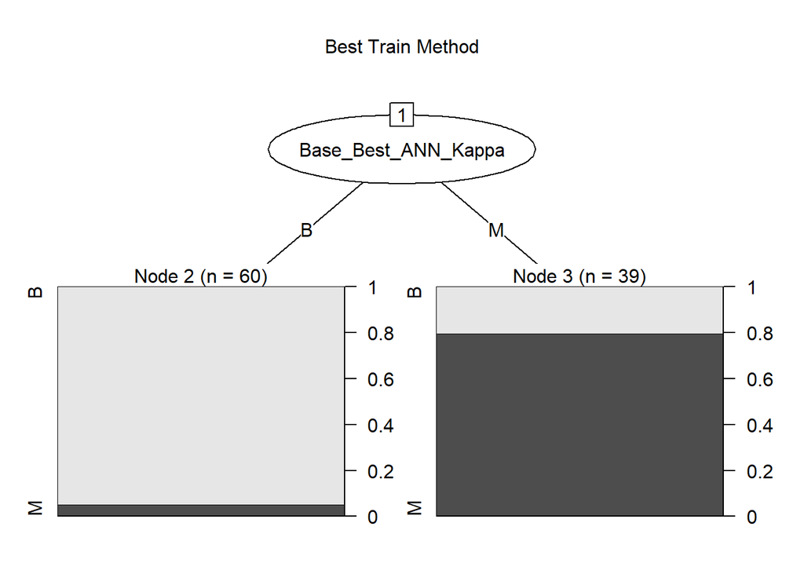

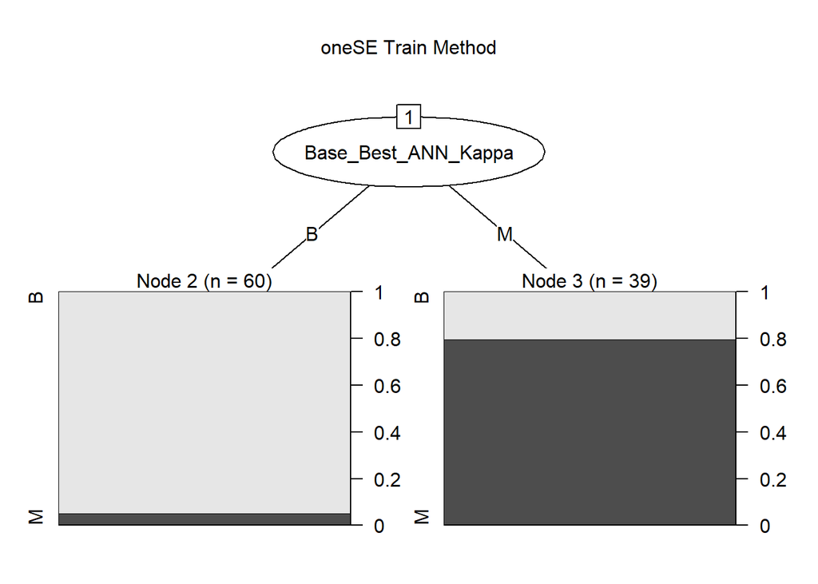

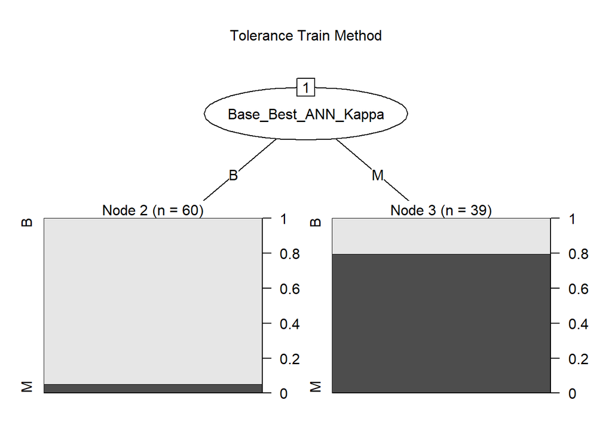

```r
base_best_tree_ann_model_plotter <- C5.0(Actual~., data = decision_tree_train_ann_model_output, cost = error_cost, model = base_best_model, trials = base_best_trials, winnow = base_best_winnow)

base_oneSE_tree_ann_model_plotter <- C5.0(Actual~., data = decision_tree_train_ann_model_output, cost = error_cost, model = base_oneSE_model, trials = base_oneSE_trials, winnow = base_oneSE_winnow)

base_tolerance_tree_ann_model_plotter <- C5.0(Actual~., data = decision_tree_train_ann_model_output, cost = error_cost, model = base_tolerance_model, trials = base_tolerance_trials, winnow = base_tolerance_winnow)
```

# Check Base level Tree Results ANN

## Best

```r
base_best_ann_tree_pred <-  predict(base_best_tree_ann_model_selector, newdata = decision_tree_train_ann_model_output, "raw")
confusionMatrix(as.factor(base_best_ann_tree_pred), decision_tree_train_ann_model_output$Actual, positive = "M")
```

```
## Confusion Matrix and Statistics
##
##           Reference
## Prediction  B  M
##          B 57  3
##          M  8 31
##
##                Accuracy : 0.8889
##                  95% CI : (0.8099, 0.9432)
##     No Information Rate : 0.6566
##     P-Value [Acc > NIR] : 0.0000001068
##
##                   Kappa : 0.762
##
##  Mcnemar's Test P-Value : 0.2278
##
##             Sensitivity : 0.9118
##             Specificity : 0.8769
##          Pos Pred Value : 0.7949
##          Neg Pred Value : 0.9500
##              Prevalence : 0.3434
##          Detection Rate : 0.3131
##    Detection Prevalence : 0.3939
##       Balanced Accuracy : 0.8943
##
##        'Positive' Class : M
##
```

## OneSE

```r
base_oneSE_ann_tree_pred <-  predict(base_oneSE_tree_ann_model_selector, newdata = decision_tree_train_ann_model_output, "raw")
confusionMatrix(as.factor(base_oneSE_ann_tree_pred), decision_tree_train_ann_model_output$Actual, positive = "M")
```

```
## Confusion Matrix and Statistics
##
##           Reference
## Prediction  B  M
##          B 57  3
##          M  8 31
##
##                Accuracy : 0.8889
##                  95% CI : (0.8099, 0.9432)
##     No Information Rate : 0.6566
##     P-Value [Acc > NIR] : 0.0000001068
##
##                   Kappa : 0.762
##
##  Mcnemar's Test P-Value : 0.2278
##
##             Sensitivity : 0.9118
##             Specificity : 0.8769
##          Pos Pred Value : 0.7949
##          Neg Pred Value : 0.9500
##              Prevalence : 0.3434
##          Detection Rate : 0.3131
##    Detection Prevalence : 0.3939
##       Balanced Accuracy : 0.8943
##
##        'Positive' Class : M
##
```

## Tolerance

```r
base_tolerance_ann_tree_pred <-  predict(base_tolerance_tree_ann_model_selector, newdata = decision_tree_train_ann_model_output, "raw")
confusionMatrix(as.factor(base_tolerance_ann_tree_pred), decision_tree_train_ann_model_output$Actual, positive = "M")
```

```
## Confusion Matrix and Statistics
##
##           Reference
## Prediction  B  M
##          B 57  3
##          M  8 31
##
##                Accuracy : 0.8889
##                  95% CI : (0.8099, 0.9432)
##     No Information Rate : 0.6566
##     P-Value [Acc > NIR] : 0.0000001068
##
##                   Kappa : 0.762
##
##  Mcnemar's Test P-Value : 0.2278
##
##             Sensitivity : 0.9118
##             Specificity : 0.8769
##          Pos Pred Value : 0.7949
##          Neg Pred Value : 0.9500
##              Prevalence : 0.3434
##          Detection Rate : 0.3131
##    Detection Prevalence : 0.3939
##       Balanced Accuracy : 0.8943
##
##        'Positive' Class : M
##
```

# Random Forest

```r
base_level_train_rf_upsampled <- upSample(x = base_level_train_rf[,-ncol(base_level_train_rf)], y = base_level_train_rf$diagnosis)
base_level_train_rf_upsampled$diagnosis <- base_level_train_rf_upsampled$Class

base_level_train_rf_upsampled$Class <- NULL

grid <- expand.grid(.mtry = seq(1, ncol(base_level_train_rf_upsampled), 1))

ctrl <- trainControl(method = "cv", number = global_cv_folds, selectionFunction = "best")

set.seed(23)
base_rf_best <- train(diagnosis~., data = base_level_train_rf_upsampled, method = "rf",
                      tuneGrid = grid,
                      metric = "Kappa",
                      trControl = ctrl)

ctrl <- trainControl(method = "cv", number = global_cv_folds, selectionFunction = "oneSE")

set.seed(23)
base_rf_oneSE <- train(diagnosis~., data = base_level_train_rf_upsampled, method = "rf",
                       tuneGrid = grid,
                       metric = "Kappa",
                       trControl = ctrl)

ctrl <- trainControl(method = "cv", number = global_cv_folds, selectionFunction = "tolerance")

set.seed(23)
base_rf_tolerance <- train(diagnosis~., data = base_level_train_rf_upsampled, method = "rf",
                           tuneGrid = grid,
                           metric = "Kappa",
                           trControl = ctrl)
```

# Create Predictions

```r
# Create Predictions
base_rf_best_pred <- predict(base_rf_best, newdata = base_level_test_rf, type = "prob")[,2]
base_rf_oneSE_pred <- predict(base_rf_oneSE, newdata = base_level_test_rf, type = "prob")[,2]
base_rf_tolerance_pred <- predict(base_rf_tolerance, newdata = base_level_test_rf, type = "prob")[,2]
```

# Optimize Prediction Threshold

## Base “Best” Random Forest Model

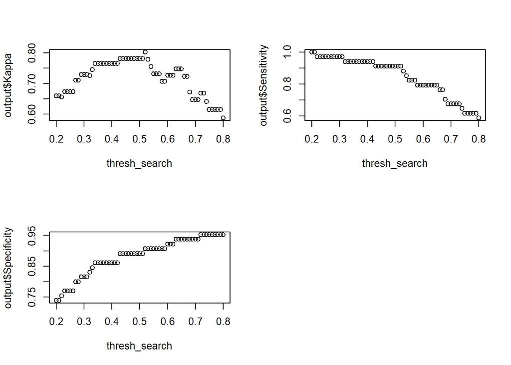

## Base “oneSE” Random Forest Model

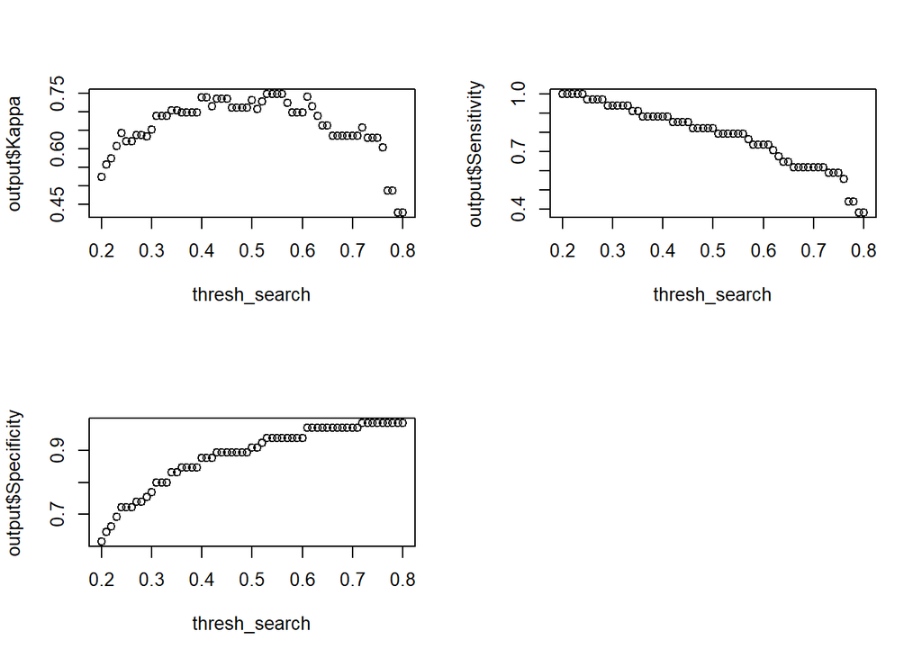

## Base “Tolerance” Random Forest Model

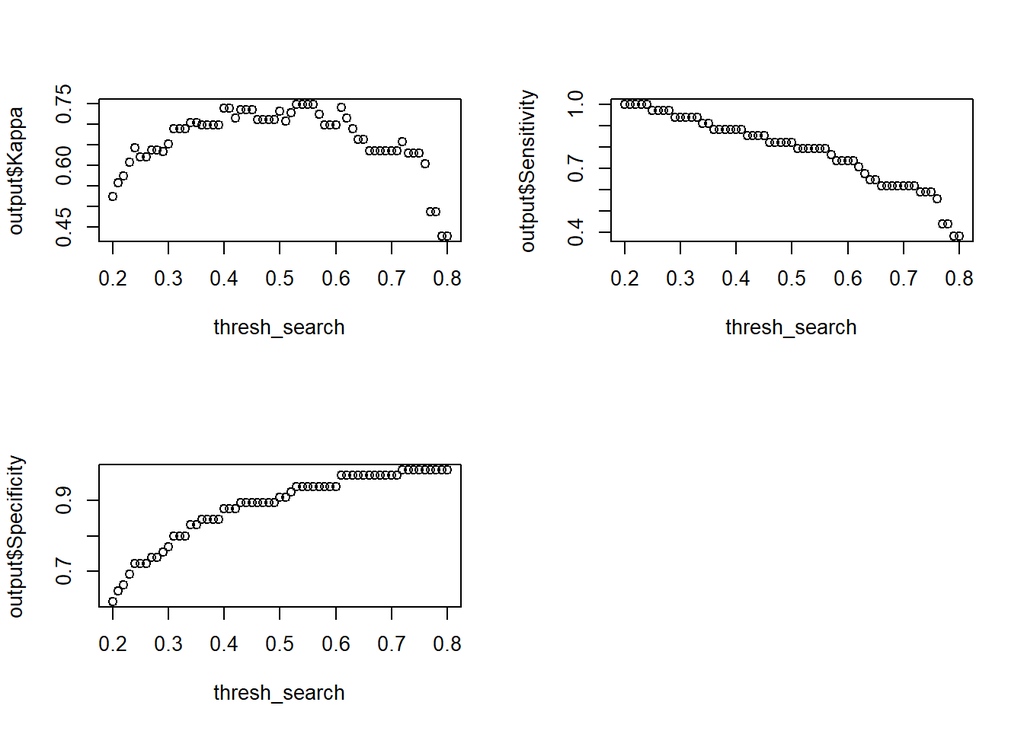

# Create Base level Test Predictions Output for the Random Forest Methods

```r
head(decision_tree_train_rf_model_output, 8)
```

```
##   Base_Best_RF_Kappa Base_Best_RF_Sensitivity Base_Best_RF_Specificity
## 1                  B                        B                        B
## 2                  M                        M                        M
## 3                  M                        M                        M
## 4                  B                        B                        B
## 5                  M                        M                        M
## 6                  B                        B                        B
## 7                  B                        B                        B
## 8                  B                        B                        B
##   Base_oneSE_RF_Kappa Base_oneSE_RF_Sensitivity Base_oneSE_RF_Specificity
## 1                   B                         B                         B
## 2                   M                         M                         M
## 3                   M                         M                         M
## 4                   B                         M                         B
## 5                   M                         M                         M
```

[output cut: 21 more lines]

# Analyze Individual Model Results

## Base Best RF Highest Kappa Model

```r
# Confusion Matrix
confusionMatrix(decision_tree_train_rf_model_output$Base_Best_RF_Kappa, decision_tree_train_rf_model_output$Actual, positive = "M")
```

```
## Confusion Matrix and Statistics
##
##           Reference
## Prediction  B  M
##          B 59  3
##          M  6 31
##
##                Accuracy : 0.9091
##                  95% CI : (0.8344, 0.9576)
##     No Information Rate : 0.6566
##     P-Value [Acc > NIR] : 0.000000005062
##
##                   Kappa : 0.8026
##
##  Mcnemar's Test P-Value : 0.505
##
##             Sensitivity : 0.9118
##             Specificity : 0.9077
##          Pos Pred Value : 0.8378
##          Neg Pred Value : 0.9516
##              Prevalence : 0.3434
##          Detection Rate : 0.3131
##    Detection Prevalence : 0.3737
##       Balanced Accuracy : 0.9097
##
##        'Positive' Class : M
##
```

## Base Best RF: Selected Sensitivity

```r
# Confusion Matrix
confusionMatrix(decision_tree_train_rf_model_output$Base_Best_RF_Sensitivity, decision_tree_train_rf_model_output$Actual, positive = "M")
```

```
## Confusion Matrix and Statistics
##
##           Reference
## Prediction  B  M
##          B 54  2
##          M 11 32
##
##                Accuracy : 0.8687
##                  95% CI : (0.7859, 0.9282)
##     No Information Rate : 0.6566
##     P-Value [Acc > NIR] : 0.000001527
##
##                   Kappa : 0.7261
##
##  Mcnemar's Test P-Value : 0.0265
##
##             Sensitivity : 0.9412
##             Specificity : 0.8308
##          Pos Pred Value : 0.7442
##          Neg Pred Value : 0.9643
##              Prevalence : 0.3434
##          Detection Rate : 0.3232
##    Detection Prevalence : 0.4343
##       Balanced Accuracy : 0.8860
##
##        'Positive' Class : M
##
```

## Base Best RF: Selected Specificity

```r
# Confusion Matrix
confusionMatrix(decision_tree_train_rf_model_output$Base_Best_RF_Specificity, decision_tree_train_rf_model_output$Actual, positive = "M")
```

```
## Confusion Matrix and Statistics
##
##           Reference
## Prediction  B  M
##          B 62 11
##          M  3 23
##
##                Accuracy : 0.8586
##                  95% CI : (0.7741, 0.9205)
##     No Information Rate : 0.6566
##     P-Value [Acc > NIR] : 0.000005077
##
##                   Kappa : 0.6678
##
##  Mcnemar's Test P-Value : 0.06137
##
##             Sensitivity : 0.6765
##             Specificity : 0.9538
##          Pos Pred Value : 0.8846
##          Neg Pred Value : 0.8493
##              Prevalence : 0.3434
##          Detection Rate : 0.2323
##    Detection Prevalence : 0.2626
##       Balanced Accuracy : 0.8152
##
##        'Positive' Class : M
##
```

## Base oneSE RF: Highest Kappa

```r
# Confusion Matrix
confusionMatrix(decision_tree_train_rf_model_output$Base_oneSE_RF_Kappa, decision_tree_train_rf_model_output$Actual, positive = "M")
```

```
## Confusion Matrix and Statistics
##
##           Reference
## Prediction  B  M
##          B 61  7
##          M  4 27
##
##                Accuracy : 0.8889
##                  95% CI : (0.8099, 0.9432)
##     No Information Rate : 0.6566
##     P-Value [Acc > NIR] : 0.0000001068
##
##                   Kappa : 0.7483
##
##  Mcnemar's Test P-Value : 0.5465
##
##             Sensitivity : 0.7941
##             Specificity : 0.9385
##          Pos Pred Value : 0.8710
##          Neg Pred Value : 0.8971
##              Prevalence : 0.3434
##          Detection Rate : 0.2727
##    Detection Prevalence : 0.3131
##       Balanced Accuracy : 0.8663
##
##        'Positive' Class : M
##
```

## Base oneSE RF: Selected Sensitivity

```r
# Confusion Matrix
confusionMatrix(decision_tree_train_rf_model_output$Base_oneSE_RF_Sensitivity, decision_tree_train_rf_model_output$Actual, positive = "M")
```

```
## Confusion Matrix and Statistics
##
##           Reference
## Prediction  B  M
##          B 49  2
##          M 16 32
##
##                Accuracy : 0.8182
##                  95% CI : (0.728, 0.8885)
##     No Information Rate : 0.6566
##     P-Value [Acc > NIR] : 0.0002942
##
##                   Kappa : 0.6329
##
##  Mcnemar's Test P-Value : 0.0021830
##
##             Sensitivity : 0.9412
##             Specificity : 0.7538
##          Pos Pred Value : 0.6667
##          Neg Pred Value : 0.9608
##              Prevalence : 0.3434
##          Detection Rate : 0.3232
##    Detection Prevalence : 0.4848
##       Balanced Accuracy : 0.8475
##
##        'Positive' Class : M
##
```

## Base oneSE RF: Selected Specificity

```r
# Confusion Matrix
confusionMatrix(decision_tree_train_rf_model_output$Base_oneSE_RF_Specificity, decision_tree_train_rf_model_output$Actual, positive = "M")
```

```
## Confusion Matrix and Statistics
##
##           Reference
## Prediction  B  M
##          B 61  7
##          M  4 27
##
##                Accuracy : 0.8889
##                  95% CI : (0.8099, 0.9432)
##     No Information Rate : 0.6566
##     P-Value [Acc > NIR] : 0.0000001068
##
##                   Kappa : 0.7483
##
##  Mcnemar's Test P-Value : 0.5465
##
##             Sensitivity : 0.7941
##             Specificity : 0.9385
##          Pos Pred Value : 0.8710
##          Neg Pred Value : 0.8971
##              Prevalence : 0.3434
##          Detection Rate : 0.2727
##    Detection Prevalence : 0.3131
##       Balanced Accuracy : 0.8663
##
##        'Positive' Class : M
##
```

## Base Tolerance RF: Highest Kappa

```r
# Confusion Matrix
confusionMatrix(decision_tree_train_rf_model_output$Base_Tolerance_RF_Kappa, decision_tree_train_rf_model_output$Actual, positive = "M")
```

```
## Confusion Matrix and Statistics
##
##           Reference
## Prediction  B  M
##          B 61  7
##          M  4 27
##
##                Accuracy : 0.8889
##                  95% CI : (0.8099, 0.9432)
##     No Information Rate : 0.6566
##     P-Value [Acc > NIR] : 0.0000001068
##
##                   Kappa : 0.7483
##
##  Mcnemar's Test P-Value : 0.5465
##
##             Sensitivity : 0.7941
##             Specificity : 0.9385
##          Pos Pred Value : 0.8710
##          Neg Pred Value : 0.8971
##              Prevalence : 0.3434
##          Detection Rate : 0.2727
##    Detection Prevalence : 0.3131
##       Balanced Accuracy : 0.8663
##
##        'Positive' Class : M
##
```

## Base Tolerance RF: Selected Sensitivity

```r
# Confusion Matrix
confusionMatrix(decision_tree_train_rf_model_output$Base_Tolerance_RF_Sensitivity, decision_tree_train_rf_model_output$Actual, positive = "M")
```

```
## Confusion Matrix and Statistics
##
##           Reference
## Prediction  B  M
##          B 49  2
##          M 16 32
##
##                Accuracy : 0.8182
##                  95% CI : (0.728, 0.8885)
##     No Information Rate : 0.6566
##     P-Value [Acc > NIR] : 0.0002942
##
##                   Kappa : 0.6329
##
##  Mcnemar's Test P-Value : 0.0021830
##
##             Sensitivity : 0.9412
##             Specificity : 0.7538
##          Pos Pred Value : 0.6667
##          Neg Pred Value : 0.9608
##              Prevalence : 0.3434
##          Detection Rate : 0.3232
##    Detection Prevalence : 0.4848
##       Balanced Accuracy : 0.8475
##
##        'Positive' Class : M
##
```

## Base Tolerance RF: Selected Specificity

```r
# Confusion Matrix
confusionMatrix(decision_tree_train_rf_model_output$Base_Tolerance_RF_Specificity, decision_tree_train_rf_model_output$Actual, positive = "M")
```

```
## Confusion Matrix and Statistics
##
##           Reference
## Prediction  B  M
##          B 61  7
##          M  4 27
##
##                Accuracy : 0.8889
##                  95% CI : (0.8099, 0.9432)
##     No Information Rate : 0.6566
##     P-Value [Acc > NIR] : 0.0000001068
##
##                   Kappa : 0.7483
##
##  Mcnemar's Test P-Value : 0.5465
##
##             Sensitivity : 0.7941
##             Specificity : 0.9385
##          Pos Pred Value : 0.8710
##          Neg Pred Value : 0.8971
##              Prevalence : 0.3434
##          Detection Rate : 0.2727
##    Detection Prevalence : 0.3131
##       Balanced Accuracy : 0.8663
##
##        'Positive' Class : M
##
```

# Train Decision Tree

# Plot Random Forest Decision Logic

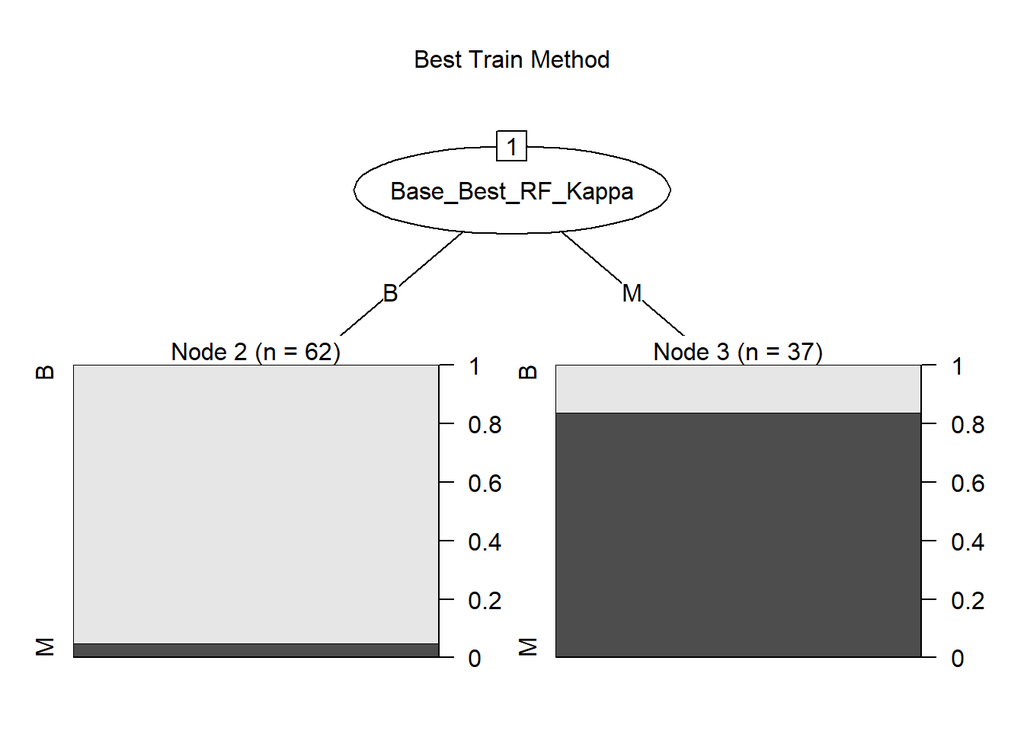

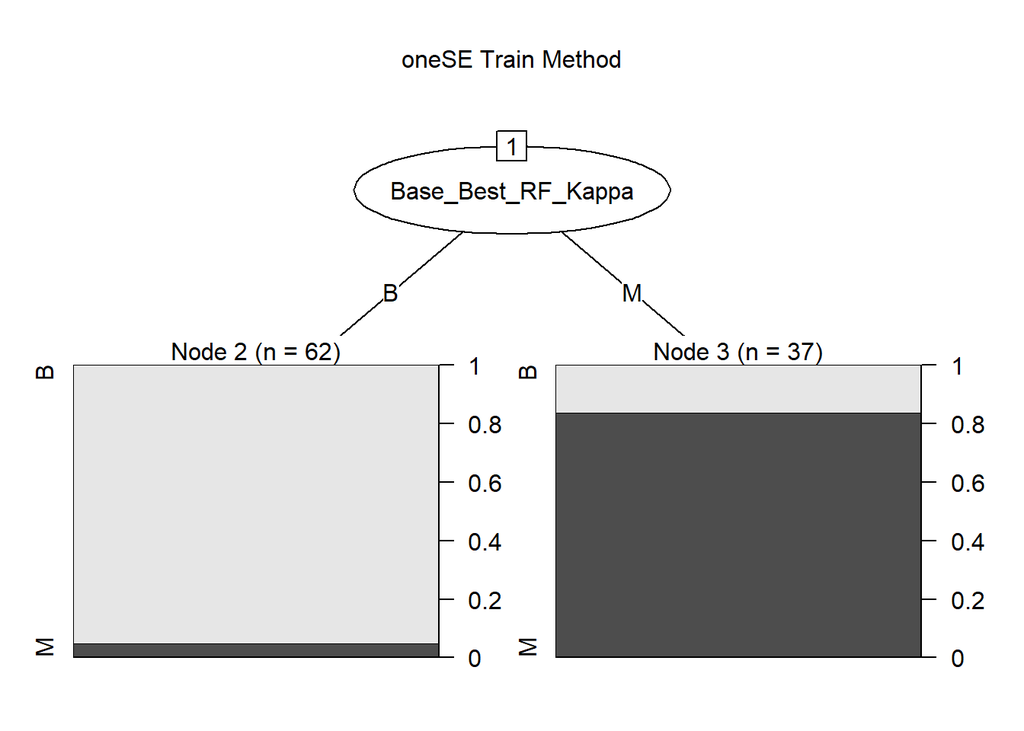

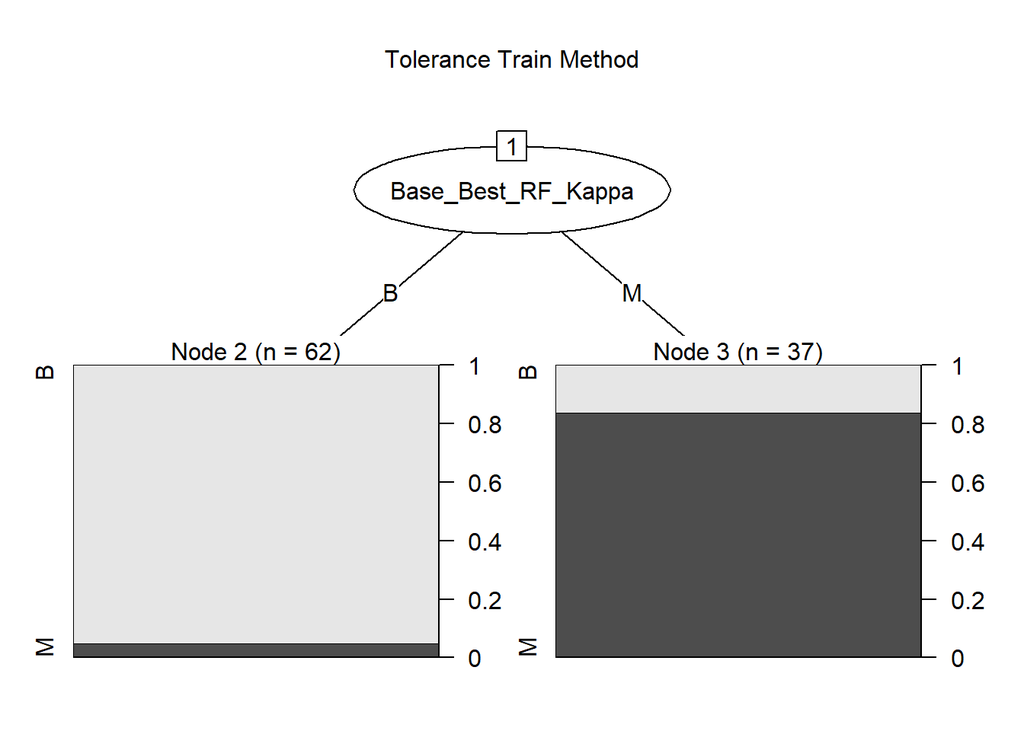

```r
base_best_tree_rf_model_plotter <- C5.0(Actual~., data = decision_tree_train_rf_model_output, cost = error_cost, model = base_best_model, trials = base_best_trials, winnow = base_best_winnow)

base_oneSE_tree_rf_model_plotter <- C5.0(Actual~., data = decision_tree_train_rf_model_output, cost = error_cost, model = base_oneSE_model, trials = base_oneSE_trials, winnow = base_oneSE_winnow)

base_tolerance_tree_rf_model_plotter <- C5.0(Actual~., data = decision_tree_train_rf_model_output, cost = error_cost, model = base_tolerance_model, trials = base_tolerance_trials, winnow = base_tolerance_winnow)
```

# Check Base level Tree Results Random Forest

## Best

```r
base_best_rf_tree_pred <-  predict(base_best_tree_rf_model_selector, newdata = decision_tree_train_rf_model_output, "raw")
confusionMatrix(as.factor(base_best_rf_tree_pred), decision_tree_train_rf_model_output$Actual, positive = "M")
```

```
## Confusion Matrix and Statistics
##
##           Reference
## Prediction  B  M
##          B 59  3
##          M  6 31
##
##                Accuracy : 0.9091
##                  95% CI : (0.8344, 0.9576)
##     No Information Rate : 0.6566
##     P-Value [Acc > NIR] : 0.000000005062
##
##                   Kappa : 0.8026
##
##  Mcnemar's Test P-Value : 0.505
##
##             Sensitivity : 0.9118
##             Specificity : 0.9077
##          Pos Pred Value : 0.8378
##          Neg Pred Value : 0.9516
##              Prevalence : 0.3434
##          Detection Rate : 0.3131
##    Detection Prevalence : 0.3737
##       Balanced Accuracy : 0.9097
##
##        'Positive' Class : M
##
```

## OneSE

```r
base_oneSE_rf_tree_pred <-  predict(base_oneSE_tree_rf_model_selector, newdata = decision_tree_train_rf_model_output, "raw")
confusionMatrix(as.factor(base_oneSE_rf_tree_pred), decision_tree_train_rf_model_output$Actual, positive = "M")
```

```
## Confusion Matrix and Statistics
##
##           Reference
## Prediction  B  M
##          B 59  3
##          M  6 31
##
##                Accuracy : 0.9091
##                  95% CI : (0.8344, 0.9576)
##     No Information Rate : 0.6566
##     P-Value [Acc > NIR] : 0.000000005062
##
##                   Kappa : 0.8026
##
##  Mcnemar's Test P-Value : 0.505
##
##             Sensitivity : 0.9118
##             Specificity : 0.9077
##          Pos Pred Value : 0.8378
##          Neg Pred Value : 0.9516
##              Prevalence : 0.3434
##          Detection Rate : 0.3131
##    Detection Prevalence : 0.3737
##       Balanced Accuracy : 0.9097
##
##        'Positive' Class : M
##
```

## Tolerance

```r
base_tolerance_rf_tree_pred <-  predict(base_tolerance_tree_rf_model_selector, newdata = decision_tree_train_rf_model_output, "raw")
confusionMatrix(as.factor(base_tolerance_rf_tree_pred), decision_tree_train_rf_model_output$Actual, positive = "M")
```

```
## Confusion Matrix and Statistics
##
##           Reference
## Prediction  B  M
##          B 59  3
##          M  6 31
##
##                Accuracy : 0.9091
##                  95% CI : (0.8344, 0.9576)
##     No Information Rate : 0.6566
##     P-Value [Acc > NIR] : 0.000000005062
##
##                   Kappa : 0.8026
##
##  Mcnemar's Test P-Value : 0.505
##
##             Sensitivity : 0.9118
##             Specificity : 0.9077
##          Pos Pred Value : 0.8378
##          Neg Pred Value : 0.9516
##              Prevalence : 0.3434
##          Detection Rate : 0.3131
##    Detection Prevalence : 0.3737
##       Balanced Accuracy : 0.9097
##
##        'Positive' Class : M
##
```

# Create Ensemble of Ensemble Decision Tree Train

```r
decision_tree_train_ensemble_of_ensembles <- cbind.data.frame(base_best_log_tree_pred, base_oneSE_log_tree_pred, base_tolerance_log_tree_pred,
                                                              base_best_knn_tree_pred, base_oneSE_knn_tree_pred, base_tolerance_knn_tree_pred,
                                                              base_best_ann_tree_pred, base_oneSE_ann_tree_pred, base_tolerance_ann_tree_pred,
                                                              base_best_rf_tree_pred, base_oneSE_rf_tree_pred, base_tolerance_rf_tree_pred,
                                                              base_level_test$diagnosis)
names(decision_tree_train_ensemble_of_ensembles) <- c("Best_Log", "OneSE_Log", "Tolerance_Log",
                                                      "Best_KNN", "OneSE_KNN", "Tolerance_KNN",
                                                      "Best_ANN", "OneSE_ANN", "Tolerance_ANN",
                                                      "Best_RF", "OneSE_RF", "Tolerance_RF",
                                                      "Actual")

head(decision_tree_train_ensemble_of_ensembles, 8)
```

```
##   Best_Log OneSE_Log Tolerance_Log Best_KNN OneSE_KNN Tolerance_KNN Best_ANN
## 1        B         B             B        B         B             B        B
## 2        M         M             M        B         M             B        M
## 3        M         M             M        M         M             M        M
## 4        M         M             M        B         M             B        B
## 5        M         M             M        M         M             M        M
## 6        B         B             B        B         B             B        B
## 7        B         B             B        B         B             B        B
## 8        B         B             B        B         B             B        B
##   OneSE_ANN Tolerance_ANN Best_RF OneSE_RF Tolerance_RF Actual
## 1         B             B       B        B            B      B
## 2         M             M       M        M            M      M
## 3         M             M       M        M            M      M
## 4         B             B       B        B            B      B
## 5         M             M       M        M            M      M
## 6         B             B       B        B            B      B
## 7         B             B       B        B            B      B
## 8         B             B       B        B            B      B
```

# Train Decision Tree Ensemble of Ensmbles

# Plot Ensemble of Ensmble Decision Logic

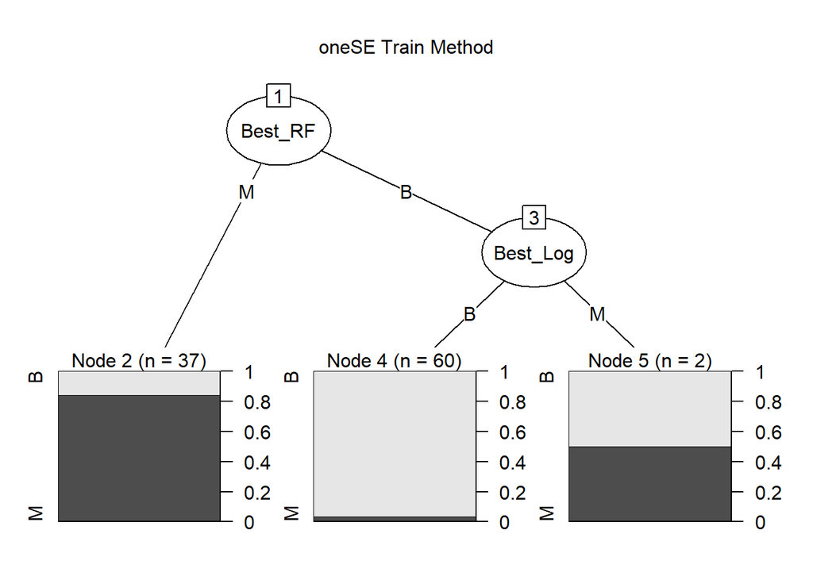

```r
base_oneSE_tree_model_plotter <- C5.0(Actual~., data = decision_tree_train_ensemble_of_ensembles, cost = error_cost, model = base_oneSE_model, trials = base_oneSE_trials, winnow = base_oneSE_winnow)
```

# Check Base level Tree Results

## OneSE

```r
base_oneSE_tree_pred <-  predict(base_oneSE_tree_model_selector, newdata = decision_tree_train_ensemble_of_ensembles, "raw")
confusionMatrix(as.factor(base_oneSE_tree_pred), decision_tree_train_ensemble_of_ensembles$Actual, positive = "M")
```

```
## Confusion Matrix and Statistics
##
##           Reference
## Prediction  B  M
##          B 58  2
##          M  7 32
##
##                Accuracy : 0.9091
##                  95% CI : (0.8344, 0.9576)
##     No Information Rate : 0.6566
##     P-Value [Acc > NIR] : 0.000000005062
##
##                   Kappa : 0.8052
##
##  Mcnemar's Test P-Value : 0.1824
##
##             Sensitivity : 0.9412
##             Specificity : 0.8923
##          Pos Pred Value : 0.8205
##          Neg Pred Value : 0.9667
##              Prevalence : 0.3434
##          Detection Rate : 0.3232
##    Detection Prevalence : 0.3939
##       Balanced Accuracy : 0.9167
##
##        'Positive' Class : M
##
```

# Create Ensemble Model

# Create Predictions

## Logistic Regression

```r
base_log_pred_final <- predict(base_log_model, newdata = final_hold_out, type = "response")
best_backward_log_pred_final <- predict(best_backward_log_model, newdata = final_hold_out, type = "response")
best_forward_log_pred_final <- predict(best_forward_log_model, newdata = final_hold_out, type = "response")
```

## KNN

```r
base_knn_best_pred_final <- predict(base_knn_best, newdata = final_hold_out_knn, type = "prob")[,2]
base_knn_oneSE_pred_final <- predict(base_knn_oneSE, newdata = final_hold_out_knn, type = "prob")[,2]
base_knn_tolerance_pred_final <- predict(base_knn_tolerance, newdata = final_hold_out_knn, type = "prob")[,2]
```

## ANN

```r
base_ann_best_pred_final <- predict(base_ann_best, newdata = final_hold_out_ann, type = "prob")[,2]
base_ann_oneSE_pred_final <- predict(base_ann_oneSE, newdata = final_hold_out_ann, type = "prob")[,2]
base_ann_tolerance_pred_final <- predict(base_ann_tolerance, newdata = final_hold_out_ann, type = "prob")[,2]
```

## Random Forest

```r
base_rf_best_pred_final <- predict(base_rf_best, newdata = final_hold_out_rf, type = "prob")[,2]
base_rf_oneSE_pred_final <- predict(base_rf_oneSE, newdata = final_hold_out_rf, type = "prob")[,2]
base_rf_tolerance_pred_final <- predict(base_rf_tolerance, newdata = final_hold_out_rf, type = "prob")[,2]
```

# Results

## Logistic Regression

### Base Log Regression Model

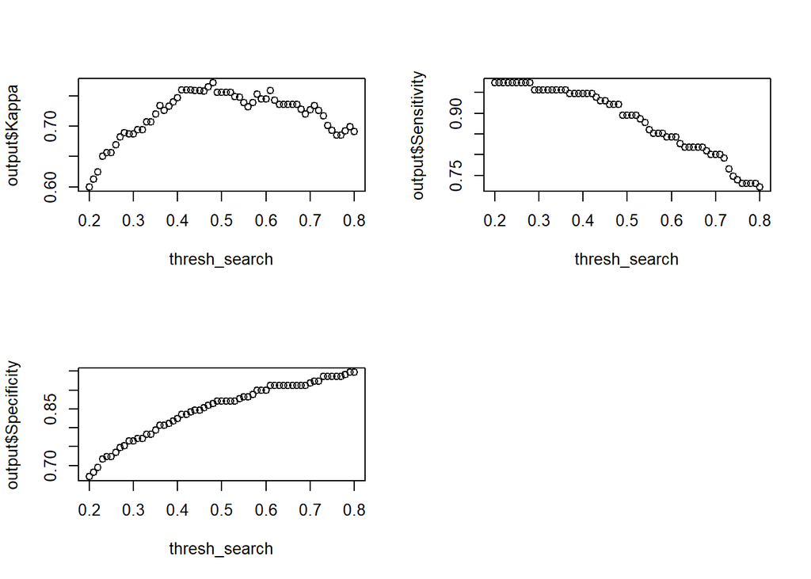

### Best Backwards Stepwise Log Regression Model

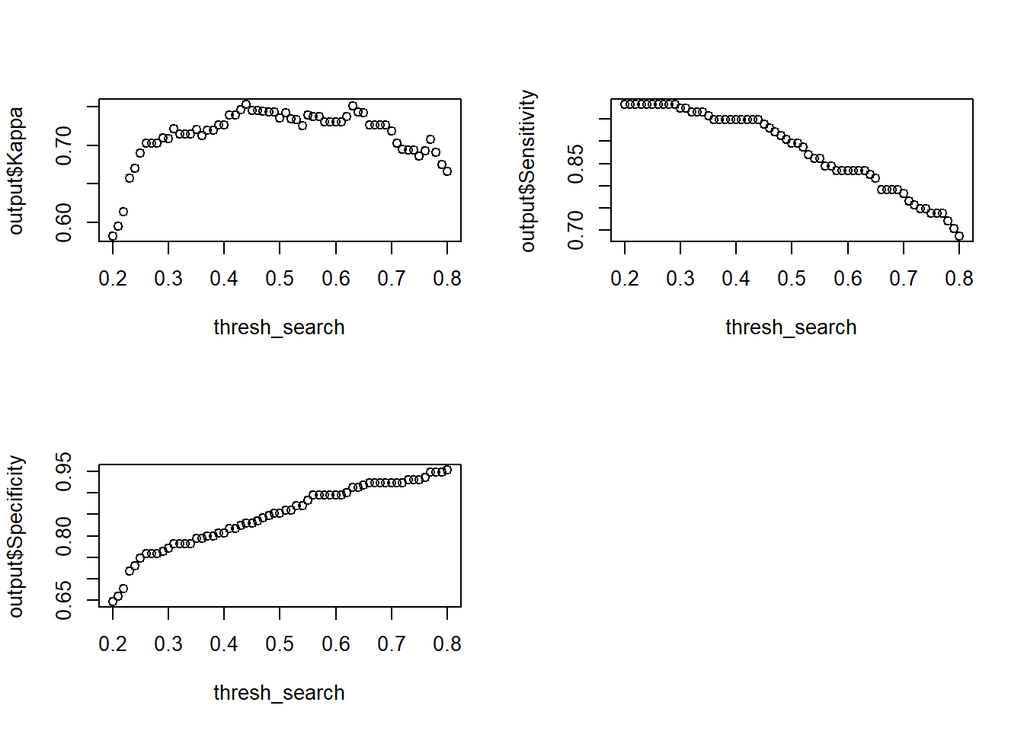

### Best Forward Stepwise Log Regression Model

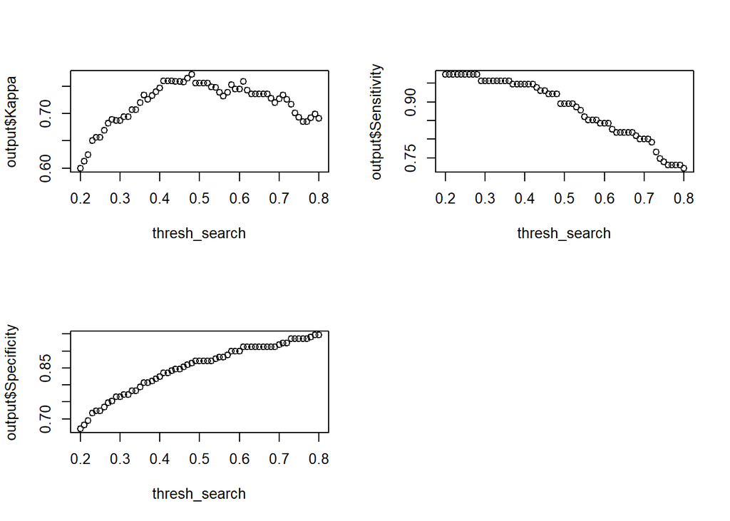

### Create Base level Test Predictions Output for the Log Regression Methods

```r
head(decision_tree_ensemble_log_model_output, 8)
```

```
##     Base_Log_Kappa Base_Log_Sensitivity Base_Log_Specificity Backward_Log_Kappa
## 37               M                    M                    B                  M
## 302              B                    B                    B                  B
## 372              B                    B                    B                  B
## 313              B                    B                    B                  B
## 109              B                    B                    B                  B
## 540              B                    B                    B                  B
## 401              B                    B                    B                  B
## 445              M                    M                    M                  M
##     Backward_Log_Sensitivity Backward_Log_Specificity Forward_Log_Kappa
## 37                         M                        B                 M
## 302                        B                        B                 B
## 372                        B                        B                 B
## 313                        B                        B                 B
## 109                        B                        B                 B
## 540                        B                        B                 B
## 401                        B                        B                 B
## 445                        M                        M                 M
##     Forward_Log_Sensitivity Forward_Log_Specificity Actual
## 37                        M                       B      M
## 302                       B                       B      B
## 372                       B                       B      B
## 313                       B                       B      B
## 109                       B                       B      B
## 540                       B                       B      B
## 401                       B                       B      B
## 445                       M                       M      M
```

### Logistic Regression Output Predictions

```r
final_log_models_prediction_best <- predict(base_best_tree_log_model_selector, decision_tree_ensemble_log_model_output, type = "raw")
confusionMatrix(final_log_models_prediction_best, decision_tree_ensemble_log_model_output$Actual, positive = "M")
```

```
## Confusion Matrix and Statistics
##
##           Reference
## Prediction   B   M
##          B 147   9
##          M  23 106
##
##                Accuracy : 0.8877
##                  95% CI : (0.8452, 0.9219)
##     No Information Rate : 0.5965
##     P-Value [Acc > NIR] : < 0.0000000000000002
##
##                   Kappa : 0.7713
##
##  Mcnemar's Test P-Value : 0.02156
##
##             Sensitivity : 0.9217
##             Specificity : 0.8647
##          Pos Pred Value : 0.8217
##          Neg Pred Value : 0.9423
##              Prevalence : 0.4035
##          Detection Rate : 0.3719
##    Detection Prevalence : 0.4526
##       Balanced Accuracy : 0.8932
##
##        'Positive' Class : M
##
```

### Logistic Regression Output Predictions

```r
final_log_models_prediction_oneSE <- predict(base_oneSE_tree_log_model_selector, decision_tree_ensemble_log_model_output, type = "raw")
confusionMatrix(final_log_models_prediction_oneSE, decision_tree_ensemble_log_model_output$Actual, positive = "M")
```

```
## Confusion Matrix and Statistics
##
##           Reference
## Prediction   B   M
##          B 147   9
##          M  23 106
##
##                Accuracy : 0.8877
##                  95% CI : (0.8452, 0.9219)
##     No Information Rate : 0.5965
##     P-Value [Acc > NIR] : < 0.0000000000000002
##
##                   Kappa : 0.7713
##
##  Mcnemar's Test P-Value : 0.02156
##
##             Sensitivity : 0.9217
##             Specificity : 0.8647
##          Pos Pred Value : 0.8217
##          Neg Pred Value : 0.9423
##              Prevalence : 0.4035
##          Detection Rate : 0.3719
##    Detection Prevalence : 0.4526
##       Balanced Accuracy : 0.8932
##
##        'Positive' Class : M
##
```

### Logistic Regression Output Predictions

```r
final_log_models_prediction_tolerance <- predict(base_tolerance_tree_log_model_selector, decision_tree_ensemble_log_model_output, type = "raw")
confusionMatrix(final_log_models_prediction_tolerance, decision_tree_ensemble_log_model_output$Actual, positive = "M")
```

```
## Confusion Matrix and Statistics
##
##           Reference
## Prediction   B   M
##          B 147   9
##          M  23 106
##
##                Accuracy : 0.8877
##                  95% CI : (0.8452, 0.9219)
##     No Information Rate : 0.5965
##     P-Value [Acc > NIR] : < 0.0000000000000002
##
##                   Kappa : 0.7713
##
##  Mcnemar's Test P-Value : 0.02156
##
##             Sensitivity : 0.9217
##             Specificity : 0.8647
##          Pos Pred Value : 0.8217
##          Neg Pred Value : 0.9423
##              Prevalence : 0.4035
##          Detection Rate : 0.3719
##    Detection Prevalence : 0.4526
##       Balanced Accuracy : 0.8932
##
##        'Positive' Class : M
##
```

## KNN

### Base “Best” KNN Model

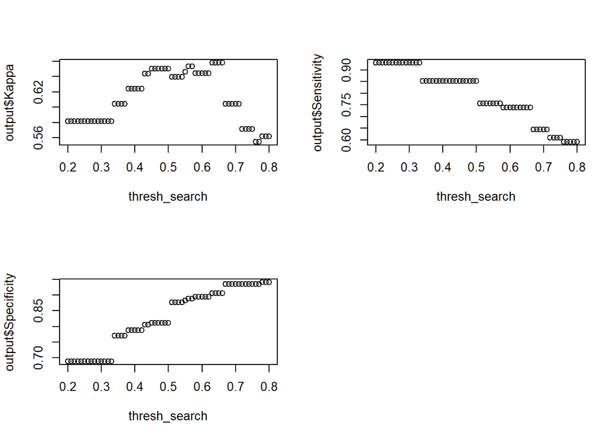

### Base “oneSE” KNN Model

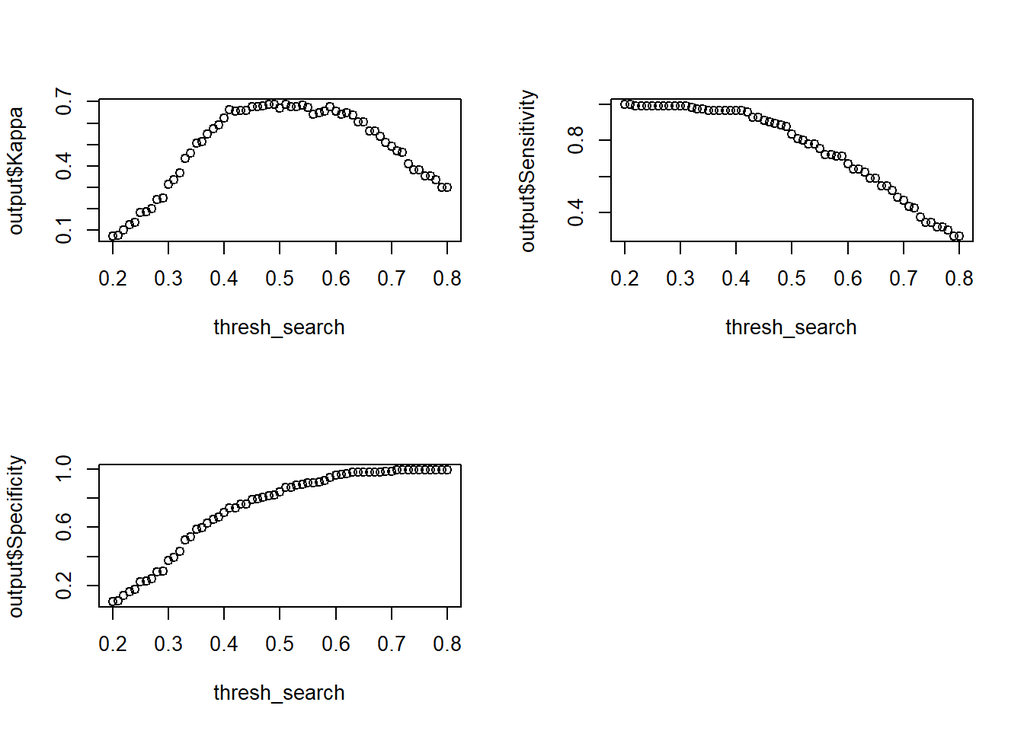

### Base “Tolerance” KNN Model

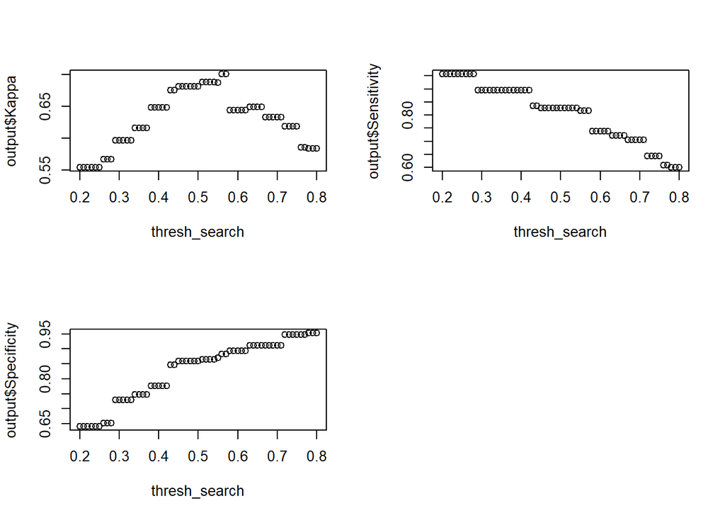

### Create Base level Test Predictions Output for the KNN Methods

### KNN Output Predictions

```r
final_knn_models_prediction_best <- predict(base_best_tree_knn_model_selector, decision_tree_ensemble_knn_model_output, type = "raw")
confusionMatrix(final_knn_models_prediction_best, decision_tree_ensemble_knn_model_output$Actual, positive = "M")
```

```
## Confusion Matrix and Statistics
##
##           Reference
## Prediction   B   M
##          B 163  38
##          M   7  77
##
##                Accuracy : 0.8421
##                  95% CI : (0.7945, 0.8824)
##     No Information Rate : 0.5965
##     P-Value [Acc > NIR] : < 0.00000000000000022
##
##                   Kappa : 0.657
##
##  Mcnemar's Test P-Value : 0.000007744
##
##             Sensitivity : 0.6696
##             Specificity : 0.9588
##          Pos Pred Value : 0.9167
##          Neg Pred Value : 0.8109
##              Prevalence : 0.4035
##          Detection Rate : 0.2702
##    Detection Prevalence : 0.2947
##       Balanced Accuracy : 0.8142
##
##        'Positive' Class : M
##
```

### KNN Output Predictions

```r
final_knn_models_prediction_oneSE <- predict(base_oneSE_tree_knn_model_selector, decision_tree_ensemble_knn_model_output, type = "raw")
confusionMatrix(final_knn_models_prediction_oneSE, decision_tree_ensemble_knn_model_output$Actual, positive = "M")
```

```
## Confusion Matrix and Statistics
##
##           Reference
## Prediction   B   M
##          B 123   5
##          M  47 110
##
##                Accuracy : 0.8175
##                  95% CI : (0.7677, 0.8606)
##     No Information Rate : 0.5965
##     P-Value [Acc > NIR] : 0.0000000000000009579
##
##                   Kappa : 0.6421
##
##  Mcnemar's Test P-Value : 0.0000000130295446166
##
##             Sensitivity : 0.9565
##             Specificity : 0.7235
##          Pos Pred Value : 0.7006
##          Neg Pred Value : 0.9609
##              Prevalence : 0.4035
##          Detection Rate : 0.3860
##    Detection Prevalence : 0.5509
##       Balanced Accuracy : 0.8400
##
##        'Positive' Class : M
##
```

### KNN Output Predictions

```r
final_knn_models_prediction_tolerance <- predict(base_tolerance_tree_knn_model_selector, decision_tree_ensemble_knn_model_output, type = "raw")
confusionMatrix(final_knn_models_prediction_tolerance, decision_tree_ensemble_knn_model_output$Actual, positive = "M")
```

```
## Confusion Matrix and Statistics
##
##           Reference
## Prediction   B   M
##          B 163  38
##          M   7  77
##
##                Accuracy : 0.8421
##                  95% CI : (0.7945, 0.8824)
##     No Information Rate : 0.5965
##     P-Value [Acc > NIR] : < 0.00000000000000022
##
##                   Kappa : 0.657
##
##  Mcnemar's Test P-Value : 0.000007744
##
##             Sensitivity : 0.6696
##             Specificity : 0.9588
##          Pos Pred Value : 0.9167
##          Neg Pred Value : 0.8109
##              Prevalence : 0.4035
##          Detection Rate : 0.2702
##    Detection Prevalence : 0.2947
##       Balanced Accuracy : 0.8142
##
##        'Positive' Class : M
##
```